# Project: Wrangling and Analyze Data

## Data Gathering

In the cell below, gather **all** three pieces of data for this project and load them in the notebook. **Note:** the methods required to gather each data are different.

1. Directly download the WeRateDogs Twitter archive data (twitter_archive_enhanced.csv)

```python
import pandas as pd
import numpy as np
import json
import requests
import tweepy
from tweepy import OAuthHandler
from timeit import default_timer as timer
import re
%matplotlib inline
import matplotlib.pyplot as plt
import seaborn as sb
```

```python
twitter_archive = pd.read_csv('twitter_archive_enhanced.csv')
```

```python
twitter_archive.head()
```

|  | tweet_id | in_reply_to_status_id | in_reply_to_user_id | timestamp | source | text | retweeted_status_id | retweeted_status_user_id | retweeted_status_timestamp | expanded_urls | rating_numerator | rating_denominator | name | doggo | floofer | pupper | puppo |
| --- | --- | --- | --- | --- | --- | --- | --- | --- | --- | --- | --- | --- | --- | --- | --- | --- | --- |
| 0 | 892420643555336193 | NaN | NaN | 2017-08-01 16:23:56 +0000 | <a href="http://twitter.com/download/iphone" r... | This is Phineas. He's a mystical boy. Only eve... | NaN | NaN | NaN | https://twitter.com/dog_rates/status/892420643... | 13 | 10 | Phineas | None | None | None | None |
| 1 | 892177421306343426 | NaN | NaN | 2017-08-01 00:17:27 +0000 | <a href="http://twitter.com/download/iphone" r... | This is Tilly. She's just checking pup on you.... | NaN | NaN | NaN | https://twitter.com/dog_rates/status/892177421... | 13 | 10 | Tilly | None | None | None | None |
| 2 | 891815181378084864 | NaN | NaN | 2017-07-31 00:18:03 +0000 | <a href="http://twitter.com/download/iphone" r... | This is Archie. He is a rare Norwegian Pouncin... | NaN | NaN | NaN | https://twitter.com/dog_rates/status/891815181... | 12 | 10 | Archie | None | None | None | None |
| 3 | 891689557279858688 | NaN | NaN | 2017-07-30 15:58:51 +0000 | <a href="http://twitter.com/download/iphone" r... | This is Darla. She commenced a snooze mid meal... | NaN | NaN | NaN | https://twitter.com/dog_rates/status/891689557... | 13 | 10 | Darla | None | None | None | None |
| 4 | 891327558926688256 | NaN | NaN | 2017-07-29 16:00:24 +0000 | <a href="http://twitter.com/download/iphone" r... | This is Franklin. He would like you to stop ca... | NaN | NaN | NaN | https://twitter.com/dog_rates/status/891327558... | 12 | 10 | Franklin | None | None | None | None |

```python
twitter_archive.info()
```

```
<class 'pandas.core.frame.DataFrame'>
RangeIndex: 2356 entries, 0 to 2355
Data columns (total 17 columns):
 #   Column                      Non-Null Count  Dtype
---  ------                      --------------  -----
 0   tweet_id                    2356 non-null   int64
 1   in_reply_to_status_id       78 non-null     float64
 2   in_reply_to_user_id         78 non-null     float64
 3   timestamp                   2356 non-null   object
 4   source                      2356 non-null   object
 5   text                        2356 non-null   object
 6   retweeted_status_id         181 non-null    float64
 7   retweeted_status_user_id    181 non-null    float64
 8   retweeted_status_timestamp  181 non-null    object
 9   expanded_urls               2297 non-null   object
 10  rating_numerator            2356 non-null   int64
 11  rating_denominator          2356 non-null   int64
 12  name                        2356 non-null   object
 13  doggo                       2356 non-null   object
 14  floofer                     2356 non-null   object
 15  pupper                      2356 non-null   object
 16  puppo                       2356 non-null   object
dtypes: float64(4), int64(3), object(10)
memory usage: 313.0+ KB
```

1. Use the Requests library to download the tweet image prediction (image_predictions.tsv)

```python
url = 'https://d17h27t6h515a5.cloudfront.net/topher/2017/August/599fd2ad_image-predictions/image-predictions.tsv'
r = requests.get(url)
```

```python
r.status_code
```

```
200
```

```python
r.content
```

[output not shown]

```python
with open('image-predictions.tsv', mode='wb') as file:
    file.write(r.content)
```

```python
img_prediction = pd.read_csv('image-predictions.tsv', sep='\t')
```

```python
img_prediction.head()
```

|  | tweet_id | jpg_url | img_num | p1 | p1_conf | p1_dog | p2 | p2_conf | p2_dog | p3 | p3_conf | p3_dog |
| --- | --- | --- | --- | --- | --- | --- | --- | --- | --- | --- | --- | --- |
| 0 | 666020888022790149 | https://pbs.twimg.com/media/CT4udn0WwAA0aMy.jpg | 1 | Welsh_springer_spaniel | 0.465074 | True | collie | 0.156665 | True | Shetland_sheepdog | 0.061428 | True |
| 1 | 666029285002620928 | https://pbs.twimg.com/media/CT42GRgUYAA5iDo.jpg | 1 | redbone | 0.506826 | True | miniature_pinscher | 0.074192 | True | Rhodesian_ridgeback | 0.072010 | True |
| 2 | 666033412701032449 | https://pbs.twimg.com/media/CT4521TWwAEvMyu.jpg | 1 | German_shepherd | 0.596461 | True | malinois | 0.138584 | True | bloodhound | 0.116197 | True |
| 3 | 666044226329800704 | https://pbs.twimg.com/media/CT5Dr8HUEAA-lEu.jpg | 1 | Rhodesian_ridgeback | 0.408143 | True | redbone | 0.360687 | True | miniature_pinscher | 0.222752 | True |
| 4 | 666049248165822465 | https://pbs.twimg.com/media/CT5IQmsXIAAKY4A.jpg | 1 | miniature_pinscher | 0.560311 | True | Rottweiler | 0.243682 | True | Doberman | 0.154629 | True |

```python
img_prediction.info()
```

```
<class 'pandas.core.frame.DataFrame'>
RangeIndex: 2075 entries, 0 to 2074
Data columns (total 12 columns):
 #   Column    Non-Null Count  Dtype
---  ------    --------------  -----
 0   tweet_id  2075 non-null   int64
 1   jpg_url   2075 non-null   object
 2   img_num   2075 non-null   int64
 3   p1        2075 non-null   object
 4   p1_conf   2075 non-null   float64
 5   p1_dog    2075 non-null   bool
 6   p2        2075 non-null   object
 7   p2_conf   2075 non-null   float64
 8   p2_dog    2075 non-null   bool
 9   p3        2075 non-null   object
 10  p3_conf   2075 non-null   float64
 11  p3_dog    2075 non-null   bool
dtypes: bool(3), float64(3), int64(2), object(4)
memory usage: 152.1+ KB
```

1. Use the Tweepy library to query additional data via the Twitter API (tweet_json.txt)

```python
df_json = []
with open('tweet_json.txt' , 'r') as file:
    for line in file:
        data = json.loads(line)

        tweet_id = data['id']
        retweet_count = data['retweet_count']
        favorite_count = data['favorite_count']
        followers_count = data['user']['followers_count']
        friends_count = data['user']['friends_count']
        verified = data['user']['verified']

        df_json.append({'tweet_id' : tweet_id ,
                        'retweet_count' : retweet_count ,
                        'favorite_count' : favorite_count ,
                        'followers_count' : followers_count ,
                        'friends_count' : friends_count ,
                        'verified' : verified})
```

```python
data
```

[output not shown]

[output cut: 45 more lines]

[output not shown]

```python
df_json
```

[output not shown]

[output cut: 5946 more lines]

[output not shown]

```python
df_json_text = pd.DataFrame(df_json , columns = ['tweet_id' ,
                                                'retweet_count' ,
                                                'favorite_count' ,
                                                'followers_count' ,
                                                'friends_count' ,
                                                'verified' ,])
```

```python
df_json_text.head()
```

|  | tweet_id | retweet_count | favorite_count | followers_count | friends_count | verified |
| --- | --- | --- | --- | --- | --- | --- |
| 0 | 892420643555336193 | 8853 | 39467 | 3200889 | 104 | True |
| 1 | 892177421306343426 | 6514 | 33819 | 3200889 | 104 | True |
| 2 | 891815181378084864 | 4328 | 25461 | 3200889 | 104 | True |
| 3 | 891689557279858688 | 8964 | 42908 | 3200889 | 104 | True |
| 4 | 891327558926688256 | 9774 | 41048 | 3200889 | 104 | True |

```python
df_json_text.to_csv('df_json.csv', index=False)
```

```python
df_json = pd.read_csv('df_json.csv')
df_json
```

|  | tweet_id | retweet_count | favorite_count | followers_count | friends_count | verified |
| --- | --- | --- | --- | --- | --- | --- |
| 0 | 892420643555336193 | 8853 | 39467 | 3200889 | 104 | True |
| 1 | 892177421306343426 | 6514 | 33819 | 3200889 | 104 | True |
| 2 | 891815181378084864 | 4328 | 25461 | 3200889 | 104 | True |
| 3 | 891689557279858688 | 8964 | 42908 | 3200889 | 104 | True |
| 4 | 891327558926688256 | 9774 | 41048 | 3200889 | 104 | True |
| ... | ... | ... | ... | ... | ... | ... |
| 2349 | 666049248165822465 | 41 | 111 | 3201018 | 104 | True |
| 2350 | 666044226329800704 | 147 | 311 | 3201018 | 104 | True |
| 2351 | 666033412701032449 | 47 | 128 | 3201018 | 104 | True |
| 2352 | 666029285002620928 | 48 | 132 | 3201018 | 104 | True |
| 2353 | 666020888022790149 | 532 | 2535 | 3201018 | 104 | True |

2354 rows × 6 columns

```python
df_json.info()
```

```
<class 'pandas.core.frame.DataFrame'>
RangeIndex: 2354 entries, 0 to 2353
Data columns (total 6 columns):
 #   Column           Non-Null Count  Dtype
---  ------           --------------  -----
 0   tweet_id         2354 non-null   int64
 1   retweet_count    2354 non-null   int64
 2   favorite_count   2354 non-null   int64
 3   followers_count  2354 non-null   int64
 4   friends_count    2354 non-null   int64
 5   verified         2354 non-null   bool
dtypes: bool(1), int64(5)
memory usage: 94.4 KB
```

## Assessing Data

```python
twitter_archive
```

|  | tweet_id | in_reply_to_status_id | in_reply_to_user_id | timestamp | source | text | retweeted_status_id | retweeted_status_user_id | retweeted_status_timestamp | expanded_urls | rating_numerator | rating_denominator | name | doggo | floofer | pupper | puppo |
| --- | --- | --- | --- | --- | --- | --- | --- | --- | --- | --- | --- | --- | --- | --- | --- | --- | --- |
| 0 | 892420643555336193 | NaN | NaN | 2017-08-01 16:23:56 +0000 | <a href="http://twitter.com/download/iphone" r... | This is Phineas. He's a mystical boy. Only eve... | NaN | NaN | NaN | https://twitter.com/dog_rates/status/892420643... | 13 | 10 | Phineas | None | None | None | None |
| 1 | 892177421306343426 | NaN | NaN | 2017-08-01 00:17:27 +0000 | <a href="http://twitter.com/download/iphone" r... | This is Tilly. She's just checking pup on you.... | NaN | NaN | NaN | https://twitter.com/dog_rates/status/892177421... | 13 | 10 | Tilly | None | None | None | None |
| 2 | 891815181378084864 | NaN | NaN | 2017-07-31 00:18:03 +0000 | <a href="http://twitter.com/download/iphone" r... | This is Archie. He is a rare Norwegian Pouncin... | NaN | NaN | NaN | https://twitter.com/dog_rates/status/891815181... | 12 | 10 | Archie | None | None | None | None |
| 3 | 891689557279858688 | NaN | NaN | 2017-07-30 15:58:51 +0000 | <a href="http://twitter.com/download/iphone" r... | This is Darla. She commenced a snooze mid meal... | NaN | NaN | NaN | https://twitter.com/dog_rates/status/891689557... | 13 | 10 | Darla | None | None | None | None |
| 4 | 891327558926688256 | NaN | NaN | 2017-07-29 16:00:24 +0000 | <a href="http://twitter.com/download/iphone" r... | This is Franklin. He would like you to stop ca... | NaN | NaN | NaN | https://twitter.com/dog_rates/status/891327558... | 12 | 10 | Franklin | None | None | None | None |
| ... | ... | ... | ... | ... | ... | ... | ... | ... | ... | ... | ... | ... | ... | ... | ... | ... | ... |
| 2351 | 666049248165822465 | NaN | NaN | 2015-11-16 00:24:50 +0000 | <a href="http://twitter.com/download/iphone" r... | Here we have a 1949 1st generation vulpix. Enj... | NaN | NaN | NaN | https://twitter.com/dog_rates/status/666049248... | 5 | 10 | None | None | None | None | None |
| 2352 | 666044226329800704 | NaN | NaN | 2015-11-16 00:04:52 +0000 | <a href="http://twitter.com/download/iphone" r... | This is a purebred Piers Morgan. Loves to Netf... | NaN | NaN | NaN | https://twitter.com/dog_rates/status/666044226... | 6 | 10 | a | None | None | None | None |
| 2353 | 666033412701032449 | NaN | NaN | 2015-11-15 23:21:54 +0000 | <a href="http://twitter.com/download/iphone" r... | Here is a very happy pup. Big fan of well-main... | NaN | NaN | NaN | https://twitter.com/dog_rates/status/666033412... | 9 | 10 | a | None | None | None | None |
| 2354 | 666029285002620928 | NaN | NaN | 2015-11-15 23:05:30 +0000 | <a href="http://twitter.com/download/iphone" r... | This is a western brown Mitsubishi terrier. Up... | NaN | NaN | NaN | https://twitter.com/dog_rates/status/666029285... | 7 | 10 | a | None | None | None | None |
| 2355 | 666020888022790149 | NaN | NaN | 2015-11-15 22:32:08 +0000 | <a href="http://twitter.com/download/iphone" r... | Here we have a Japanese Irish Setter. Lost eye... | NaN | NaN | NaN | https://twitter.com/dog_rates/status/666020888... | 8 | 10 | None | None | None | None | None |

2356 rows × 17 columns

```python
twitter_archive.sample(5)
```

|  | tweet_id | in_reply_to_status_id | in_reply_to_user_id | timestamp | source | text | retweeted_status_id | retweeted_status_user_id | retweeted_status_timestamp | expanded_urls | rating_numerator | rating_denominator | name | doggo | floofer | pupper | puppo |
| --- | --- | --- | --- | --- | --- | --- | --- | --- | --- | --- | --- | --- | --- | --- | --- | --- | --- |
| 559 | 803276597545603072 | NaN | NaN | 2016-11-28 16:37:19 +0000 | <a href="http://twitter.com/download/iphone" r... | This is Winston. His selfie game is legendary.... | NaN | NaN | NaN | https://twitter.com/dog_rates/status/803276597... | 11 | 10 | Winston | None | None | None | None |
| 837 | 767754930266464257 | NaN | NaN | 2016-08-22 16:06:54 +0000 | <a href="http://twitter.com/download/iphone" r... | This is Philbert. His toilet broke and he does... | NaN | NaN | NaN | https://twitter.com/dog_rates/status/767754930... | 11 | 10 | Philbert | None | None | None | None |
| 777 | 776088319444877312 | NaN | NaN | 2016-09-14 16:00:49 +0000 | <a href="http://twitter.com/download/iphone" r... | I can't tap the screen to make the hearts appe... | NaN | NaN | NaN | https://twitter.com/dog_rates/status/776088319... | 10 | 10 | None | None | None | None | None |
| 1148 | 726887082820554753 | NaN | NaN | 2016-05-01 21:32:40 +0000 | <a href="http://twitter.com/download/iphone" r... | This is Blitz. He's a new dad struggling to co... | NaN | NaN | NaN | https://twitter.com/dog_rates/status/726887082... | 10 | 10 | Blitz | None | None | None | None |
| 1382 | 700864154249383937 | NaN | NaN | 2016-02-20 02:06:50 +0000 | <a href="http://twitter.com/download/iphone" r... | "Pupper is a present to world. Here is a bow f... | NaN | NaN | NaN | https://twitter.com/dog_rates/status/700864154... | 12 | 10 | a | None | None | pupper | None |

```python
not_dogs = twitter_archive[twitter_archive['text'].str.contains('only rate dogs' ,  na = False)]
not_dogs.text.tolist()
```

```
['This... is a Jubilant Antarctic House Bear. We only rate dogs. Please only send dogs. Thank you... 12/10 would suffocate in floof https://t.co/4Ad1jzJSdp',
 "Ugh not again. We only rate dogs. Please don't send in well-dressed  floppy-tongued street penguins. Dogs only please. Thank you... 12/10 https://t.co/WiAMbTkDPf",
 "I can't believe this keeps happening. This, is a birb taking a bath. We only rate dogs. Please only send dogs. Thank you... 12/10 https://t.co/pwY9PQhtP2",
 "RT @dog_rates: We only rate dogs. This is quite clearly a smol broken polar bear. We'd appreciate if you only send dogs. Thank you... 12/10…",
 'Unbelievable. We only rate dogs. Please don\'t send in non-canines like the "I" from Pixar\'s opening credits. Thank you... 12/10 https://t.co/JMhDNv5wXZ',
 "Oh my this spooked me up. We only rate dogs, not happy ghosts. Please send dogs only. It's a very simple premise. Thank you... 13/10 https://t.co/M5Rz0R8SIQ",
 "We only rate dogs. Please don't send in Jesus. We're trying to remain professional and legitimate. Thank you... 14/10 https://t.co/wr3xsjeCIR",
 "We only rate dogs. Please don't send perfectly toasted marshmallows attempting to drive. Thank you... 13/10 https://t.co/nvZyyrp0kd",
 "We only rate dogs. This is quite clearly a smol broken polar bear. We'd appreciate if you only send dogs. Thank you... 12/10 https://t.co/g2nSyGenG9",
 "Guys, we only rate dogs. This is quite clearly a bulbasaur. Please only send dogs. Thank you... 12/10 human used pet, it's super effective https://t.co/Xc7uj1C64x",
 'Seriously guys? Again? We only rate dogs. Please stop submitting other things like this super good hammerhead shark. Thank you... 12/10 https://t.co/TCMC90mSOT',
 'Please stop sending in animals other than dogs. We only rate dogs. Not Furry Ecuadorian Sea Turtles. Thank you... 12/10 https://t.co/UOE79zb6VU',
 "C'mon guys. Please only send in dogs. We only rate dogs, not Exceptional-Tongued Peruvian Floor Bears. Thank you... 12/10 https://t.co/z30iQLiXNo",
 "We only rate dogs. Please don't send in any non-canines like this Floppy Tongued House Panda. Thank you... 12/10 would still pet https://t.co/8fX2VkExnL",
 'RT @dog_rates: Please only send in dogs. We only rate dogs, not seemingly heartbroken ewoks. Thank you... still 10/10 would console https:/…',
 "We only rate dogs. Please don't send in any more non-dogs like this Wild Albanian Street Moose. Thank you... 11/10 https://t.co/srXL2s868C",
 "RT @dog_rates: We only rate dogs. Please don't send pics of men capturing low level clouds. Thank you... 11/10 https://t.co/rLi83ZyCL5",
 'Please stop sending in non-canines like this Very Pettable Dozing Bath Tortoise. We only rate dogs. Only send dogs... 12/10 https://t.co/mcagPeENIh',
 "We only rate dogs. Please don't send pics of men capturing low level clouds. Thank you... 11/10 https://t.co/rLi83ZyCL5",
 "We only rate dogs. Please don't send in other things like this very good Christmas tree. Thank you... 13/10 https://t.co/rvSANEsQZJ",
 'RT @dog_rates: Meet Sammy. At first I was like "that\'s a snowflake. we only rate dogs," but he would\'ve melted by now, so 10/10 https://t.c…',
 'Please only send in dogs. We only rate dogs, not seemingly heartbroken ewoks. Thank you... still 10/10 would console https://t.co/HIraYS1Bzo',
 'RT @dog_rates: Idk why this keeps happening. We only rate dogs. Not Bangladeshi Couch Chipmunks. Please only send dogs... 12/10 https://t.c…',
 'We only rate dogs. Please stop sending in non-canines like this Freudian Poof Lion. This is incredibly frustrating... 11/10 https://t.co/IZidSrBvhi',
 'Idk why this keeps happening. We only rate dogs. Not Bangladeshi Couch Chipmunks. Please only send dogs... 12/10 https://t.co/ya7bviQUUf',
 "We only rate dogs. Pls stop sending in non-canines like this Urban Floof Giraffe. I can't handle this. 11/10 https://t.co/zHIqpM5Gni",
 'RT @dog_rates: This is an East African Chalupa Seal. We only rate dogs. Please only send in dogs. Thank you... 10/10 https://t.co/iHe6liLwWR',
 'RT @dog_rates: We only rate dogs. Pls stop sending in non-canines like this Mongolian grass snake. This is very frustrating. 11/10 https://…',
 'Guys this is getting so out of hand. We only rate dogs. This is a Galapagos Speed Panda. Pls only send dogs... 10/10 https://t.co/8lpAGaZRFn',
 'We only rate dogs. Pls stop sending in non-canines like this Arctic Floof Kangaroo. This is very frustrating. 11/10 https://t.co/qlUDuPoE3d',
 'RT @dog_rates: We only rate dogs... this is a Taiwanese Guide Walrus. Im getting real heckin tired of this. Please send dogs. 10/10 https:/…',
 "Guys.. we only rate dogs. Pls don't send any more pics of the Loch Ness Monster. Only send in dogs. Thank you. 11/10 https://t.co/obH5vMbm1j",
 'We only rate dogs... this is a Taiwanese Guide Walrus. Im getting real heckin tired of this. Please send dogs. 10/10 https://t.co/49hkNAsubi',
 'RT @dog_rates: This... is a Tyrannosaurus rex. We only rate dogs. Please only send in dogs. Thank you ...10/10 https://t.co/zxw8d5g94P',
 'This is a carrot. We only rate dogs. Please only send in dogs. You all really should know this by now ...11/10 https://t.co/9e48aPrBm2',
 'We only rate dogs. Pls stop sending in non-canines like this Jamaican Flop Seal. This is very very frustrating. 9/10 https://t.co/nc53zEN0hZ',
 'This is getting incredibly frustrating. This is a Mexican Golden Beaver. We only rate dogs. Only send dogs ...10/10 https://t.co/0yolOOyD3X',
 'This... is a Tyrannosaurus rex. We only rate dogs. Please only send in dogs. Thank you ...10/10 https://t.co/zxw8d5g94P',
 'For the last time, we only rate dogs. Pls stop sending other animals like this Duck-Billed Platypus. Thank you. 9/10 https://t.co/twxYcPOafl',
 'We only rate dogs. Pls stop sending in non-canines like this Slovak Car Bunny. It makes my job very difficult. 11/10 https://t.co/VflvQLH2y5',
```

[output cut: 9 more lines]

```
 'Really guys? Again? I know this is a rare Albanian Bingo Seal, but we only rate dogs. Only send in dogs... 9/10 https://t.co/6JYLpUmBrC',
 'This is an East African Chalupa Seal. We only rate dogs. Please only send in dogs. Thank you... 10/10 https://t.co/iHe6liLwWR',
 'We only rate dogs. Pls stop sending in non-canines like this Mongolian grass snake. This is very frustrating. 11/10 https://t.co/22x9SbCYCU',
 'Please stop sending in saber-toothed tigers. This is getting ridiculous. We only rate dogs.\n...8/10 https://t.co/iAeQNueou8',
 'Stop sending in lobsters. This is the final warning. We only rate dogs. Thank you... 9/10 https://t.co/B9ZXXKJYNx',
 "Please send dogs. I'm tired of seeing other stuff like this dangerous pirate. We only rate dogs. Thank you... 10/10 https://t.co/YdLytdZOqv",
 'For the last time, WE. DO. NOT. RATE. BULBASAUR. We only rate dogs. Please only send dogs. Thank you ...9/10 https://t.co/GboDG8WhJG',
 'This is actually a lion. We only rate dogs. For the last time please only send dogs. Thank u.\n12/10 would still pet https://t.co/Pp26dMQxap',
 'I thought I made this very clear. We only rate dogs. Stop sending other things like this shark. Thank you... 9/10 https://t.co/CXSJZ4Stk3',
 'Meet Sammy. At first I was like "that\'s a snowflake. we only rate dogs," but he would\'ve melted by now, so 10/10 https://t.co/MQfPK4zwuh',
 "Guys this really needs to stop. We've been over this way too many times. This is a giraffe. We only rate dogs.. 7/10 https://t.co/yavgkHYPOC",
 "I know everyone's excited for Christmas but that doesn't mean you can send in reindeer. We only rate dogs... 8/10 https://t.co/eWjWgbOCYL",
 'Seriously guys?! Only send in dogs. I only rate dogs. This is a baby black bear... 11/10 https://t.co/H7kpabTfLj',
 "C'mon guys. We've been over this. We only rate dogs. This is a cow. Please only submit dogs. Thank you...... 9/10 https://t.co/WjcELNEqN2",
 "Guys I'm getting real tired of this. We only rate dogs. Please don't send in other things like this Bulbasaur. 3/10 https://t.co/t5rQHl6W8M"]
```

```python
len(not_dogs)
```

```
64
```

```python
url_text = twitter_archive[twitter_archive['text'].str.contains('https' ,  na = False)]
url_text.text.tolist()
```

```
["This is Phineas. He's a mystical boy. Only ever appears in the hole of a donut. 13/10 https://t.co/MgUWQ76dJU",
 "This is Tilly. She's just checking pup on you. Hopes you're doing ok. If not, she's available for pats, snugs, boops, the whole bit. 13/10 https://t.co/0Xxu71qeIV",
 'This is Archie. He is a rare Norwegian Pouncing Corgo. Lives in the tall grass. You never know when one may strike. 12/10 https://t.co/wUnZnhtVJB',
 'This is Darla. She commenced a snooze mid meal. 13/10 happens to the best of us https://t.co/tD36da7qLQ',
 'This is Franklin. He would like you to stop calling him "cute." He is a very fierce shark and should be respected as such. 12/10 #BarkWeek https://t.co/AtUZn91f7f',
 "Here we have a majestic great white breaching off South Africa's coast. Absolutely h*ckin breathtaking. 13/10 (IG: tucker_marlo) #BarkWeek https://t.co/kQ04fDDRmh",
 'Meet Jax. He enjoys ice cream so much he gets nervous around it. 13/10 help Jax enjoy more things by clicking below\n\nhttps://t.co/Zr4hWfAs1H https://t.co/tVJBRMnhxl',
 "When you watch your owner call another dog a good boy but then they turn back to you and say you're a great boy. 13/10 https://t.co/v0nONBcwxq",
 "This is Zoey. She doesn't want to be one of the scary sharks. Just wants to be a snuggly pettable boatpet. 13/10 #BarkWeek https://t.co/9TwLuAGH0b",
 'This is Cassie. She is a college pup. Studying international doggo communication and stick theory. 14/10 so elegant much sophisticate https://t.co/t1bfwz5S2A',
 'This is Koda. He is a South Australian deckshark. Deceptively deadly. Frighteningly majestic. 13/10 would risk a petting #BarkWeek https://t.co/dVPW0B0Mme',
 'This is Bruno. He is a service shark. Only gets out of the water to assist you. 13/10 terrifyingly good boy https://t.co/u1XPQMl29g',
 "Here's a puppo that seems to be on the fence about something haha no but seriously someone help her. 13/10 https://t.co/BxvuXk0UCm",
 "This is Ted. He does his best. Sometimes that's not enough. But it's ok. 12/10 would assist https://t.co/f8dEDcrKSR",
 "This is Stuart. He's sporting his favorite fanny pack. Secretly filled with bones only. 13/10 puppared puppo #BarkWeek https://t.co/y70o6h3isq",
 "This is Oliver. You're witnessing one of his many brutal attacks. Seems to be playing with his victim. 13/10 fr*ckin frightening #BarkWeek https://t.co/WpHvrQedPb",
 'This is Jim. He found a fren. Taught him how to sit like the good boys. 12/10 for both https://t.co/chxruIOUJN',
 'This is Zeke. He has a new stick. Very proud of it. Would like you to throw it for him without taking it. 13/10 would do my best https://t.co/HTQ77yNQ5K',
 "This is Ralphus. He's powering up. Attempting maximum borkdrive. 13/10 inspirational af https://t.co/YnYAFCTTiK",
 'RT @dog_rates: This is Canela. She attempted some fancy porch pics. They were unsuccessful. 13/10 someone help her https://t.co/cLyzpcUcMX',
 "This is Gerald. He was just told he didn't get the job he interviewed for. A h*ckin injustice. 12/10 didn't want the job anyway https://t.co/DK7iDPfuRX",
 "This is Jeffrey. He has a monopoly on the pool noodles. Currently running a 'boop for two' midweek sale. 13/10 h*ckin strategic https://t.co/PhrUk20Q64",
 "I've yet to rate a Venezuelan Hover Wiener. This is such an honor. 14/10 paw-inspiring af (IG: roxy.thedoxy) https://t.co/20VrLAA8ba",
 'This is Canela. She attempted some fancy porch pics. They were unsuccessful. 13/10 someone help her https://t.co/cLyzpcUcMX',
 'You may not have known you needed to see this today. 13/10 please enjoy (IG: emmylouroo) https://t.co/WZqNqygEyV',
 'This... is a Jubilant Antarctic House Bear. We only rate dogs. Please only send dogs. Thank you... 12/10 would suffocate in floof https://t.co/4Ad1jzJSdp',
 "This is Maya. She's very shy. Rarely leaves her cup. 13/10 would find her an environment to thrive in https://t.co/I6oNy0CgiT",
 "This is Mingus. He's a wonderful father to his smol pup. Confirmed 13/10, but he needs your help\n\nhttps://t.co/bVi0Yr4Cff https://t.co/ISvKOSkd5b",
 "This is Derek. He's late for a dog meeting. 13/10 pet...al to the metal https://t.co/BCoWue0abA",
 'This is Roscoe. Another pupper fallen victim to spontaneous tongue ejections. Get the BlepiPen immediate. 12/10 deep breaths Roscoe https://t.co/RGE08MIJox',
 'This is Waffles. His doggles are pupside down. Unsure how to fix. 13/10 someone assist Waffles https://t.co/xZDA9Qsq1O',
 'RT @Athletics: 12/10 #BATP https://t.co/WxwJmvjfxo',
 'Viewer discretion advised. This is Jimbo. He will rip ur finger right h*ckin off. Other dog clearly an accessory. 12/10 pls pet with caution https://t.co/BuveP0uMF1',
 'This is Maisey. She fell asleep mid-excavation. Happens to the best of us. 13/10 would pat noggin approvingly https://t.co/tp1kQ8i9JF',
 'I have a new hero and his name is Howard. 14/10 https://t.co/gzLHboL7Sk',
 'RT @dog_rates: This is Lilly. She just parallel barked. Kindly requests a reward now. 13/10 would pet so well https://t.co/SATN4If5H5',
 'Here we have a corgi undercover as a malamute. Pawbably doing important investigative work. Zero control over tongue happenings. 13/10 https://t.co/44ItaMubBf',
 "This is Earl. He found a hat. Nervous about what you think of it. 12/10 it's delightful, Earl https://t.co/MYJvdlNRVa",
 "This is Lola. It's her first time outside. Must test the earth and taste the atmosphere. 13/10 you're doing great Lola https://t.co/74TKAUsLkO",
 "This is Kevin. He's just so happy. 13/10 what is your secret Kevin https://t.co/1r4MFCbCX5",
```

[output cut: 946 more lines]

```
 'We only rate dogs. Pls stop sending in non-canines like this Jamaican Flop Seal. This is very very frustrating. 9/10 https://t.co/nc53zEN0hZ',
 'This is Sugar. She excels underwater. 12/10 photogenic af https://t.co/AWMeXJJz64',
 "This is Jeffrey. He wasn't prepared to execute such advanced barkour. Still 11/10 would totally pet https://t.co/MuuwkkLrHh",
 "This is Oliver. He's downright gorgeous as hell. Should be on the cover of Dogue. 12/10 would introduce to mom https://t.co/BkgU3rrsXA",
 'This is Abby. She got her face stuck in a glass. Churlish af. 9/10 rookie move puppo https://t.co/2FPb45NXrK',
 "Say hello to Indie and Jupiter. They're having a stellar day out on the boat. Both 12/10 adorbz af https://t.co/KgSEkrPA3r",
 "This is Harvey. He's stealthy af. 10/10 would do my best to pet https://t.co/zAzaRT6NnT",
 'This is Blanket. She has overthrown her human. Demands walks like this every hour on the hour. 11/10 so damn fluffy https://t.co/hrJugNHs2Z',
 "Here's a doggo realizing you can stand in a pool. 13/10 enlightened af (vid by Tina Conrad) https://t.co/7wE9LTEXC4",
 "This is actually a pupper and I'd pet it so well. 12/10\nhttps://t.co/RNqS7C4Y4N",
 "This is Geno. He's a Wrinkled Baklavian Velveeta. Looks sad but that's just the extra skin. 11/10 would smoosh face https://t.co/Kxda28JmQ2",
 "When you're given AUX cord privileges from the back seat and accidentally start blasting an audiobook... both 10/10 https://t.co/gCCrY8P0K9",
 'RT @dog_rates: Extremely intelligent dog here. Has learned to walk like human. Even has his own dog. Very impressive 10/10 https://t.co/0Dv…',
 'Meet Stark. He just had his first ice cream cone. Got some on his nose. Requests your assistance. 10/10 would assist https://t.co/YwfN1lbpKA',
 ...]
```

```python
twitter_archive.info()
```

```
<class 'pandas.core.frame.DataFrame'>
RangeIndex: 2356 entries, 0 to 2355
Data columns (total 17 columns):
 #   Column                      Non-Null Count  Dtype
---  ------                      --------------  -----
 0   tweet_id                    2356 non-null   int64
 1   in_reply_to_status_id       78 non-null     float64
 2   in_reply_to_user_id         78 non-null     float64
 3   timestamp                   2356 non-null   object
 4   source                      2356 non-null   object
 5   text                        2356 non-null   object
 6   retweeted_status_id         181 non-null    float64
 7   retweeted_status_user_id    181 non-null    float64
 8   retweeted_status_timestamp  181 non-null    object
 9   expanded_urls               2297 non-null   object
 10  rating_numerator            2356 non-null   int64
 11  rating_denominator          2356 non-null   int64
 12  name                        2356 non-null   object
 13  doggo                       2356 non-null   object
 14  floofer                     2356 non-null   object
 15  pupper                      2356 non-null   object
 16  puppo                       2356 non-null   object
dtypes: float64(4), int64(3), object(10)
memory usage: 313.0+ KB
```

```python
img_prediction.info()
```

```
<class 'pandas.core.frame.DataFrame'>
RangeIndex: 2075 entries, 0 to 2074
Data columns (total 12 columns):
 #   Column    Non-Null Count  Dtype
---  ------    --------------  -----
 0   tweet_id  2075 non-null   int64
 1   jpg_url   2075 non-null   object
 2   img_num   2075 non-null   int64
 3   p1        2075 non-null   object
 4   p1_conf   2075 non-null   float64
 5   p1_dog    2075 non-null   bool
 6   p2        2075 non-null   object
 7   p2_conf   2075 non-null   float64
 8   p2_dog    2075 non-null   bool
 9   p3        2075 non-null   object
 10  p3_conf   2075 non-null   float64
 11  p3_dog    2075 non-null   bool
dtypes: bool(3), float64(3), int64(2), object(4)
memory usage: 152.1+ KB
```

```python
img_prediction.sample(5)
```

|  | tweet_id | jpg_url | img_num | p1 | p1_conf | p1_dog | p2 | p2_conf | p2_dog | p3 | p3_conf | p3_dog |
| --- | --- | --- | --- | --- | --- | --- | --- | --- | --- | --- | --- | --- |
| 922 | 702217446468493312 | https://pbs.twimg.com/media/Cb7HCMkWEAAV9zY.jpg | 1 | golden_retriever | 0.242419 | True | chow | 0.226800 | True | cocker_spaniel | 0.194086 | True |
| 1015 | 709852847387627521 | https://pbs.twimg.com/media/CdnnZhhWAAEAoUc.jpg | 2 | Chihuahua | 0.945629 | True | Pomeranian | 0.019204 | True | West_Highland_white_terrier | 0.010134 | True |
| 720 | 685943807276412928 | https://pbs.twimg.com/ext_tw_video_thumb/68594... | 1 | papillon | 0.200812 | True | toy_terrier | 0.114512 | True | Cardigan | 0.094520 | True |
| 1477 | 780543529827336192 | https://pbs.twimg.com/media/CtUMLzRXgAAbZK5.jpg | 1 | golden_retriever | 0.628312 | True | Labrador_retriever | 0.317365 | True | Tibetan_mastiff | 0.012260 | True |
| 1356 | 760539183865880579 | https://pbs.twimg.com/media/Co36VZfWcAEN3R3.jpg | 1 | Samoyed | 0.988013 | True | malamute | 0.004518 | True | West_Highland_white_terrier | 0.001189 | True |

```python
df_json.sample(5)
```

|  | tweet_id | retweet_count | favorite_count | followers_count | friends_count | verified |
| --- | --- | --- | --- | --- | --- | --- |
| 1766 | 678389028614488064 | 473 | 2044 | 3200954 | 104 | True |
| 54 | 881633300179243008 | 7 | 129 | 3200890 | 104 | True |
| 143 | 863907417377173506 | 4441 | 21477 | 3200891 | 104 | True |
| 161 | 860524505164394496 | 5698 | 24678 | 3200891 | 104 | True |
| 1140 | 727524757080539137 | 1379 | 4900 | 3200945 | 104 | True |

```python
df_json.info()
```

```
<class 'pandas.core.frame.DataFrame'>
RangeIndex: 2354 entries, 0 to 2353
Data columns (total 6 columns):
 #   Column           Non-Null Count  Dtype
---  ------           --------------  -----
 0   tweet_id         2354 non-null   int64
 1   retweet_count    2354 non-null   int64
 2   favorite_count   2354 non-null   int64
 3   followers_count  2354 non-null   int64
 4   friends_count    2354 non-null   int64
 5   verified         2354 non-null   bool
dtypes: bool(1), int64(5)
memory usage: 94.4 KB
```

### Quality issues

1. tweet_id across all three tables should be "string" not "int"
2. Null represented as None in the name, doggo, floofer, pupper and puppo columns of the twitter_archive table
3. Timestamp is saved as object datatype instead of datetime in the twitter_archive table
4. Missing Values in the twitter_archive table:

> in_reply_to_status_id, in_reply_to_user_id have 78 entries instead of 2356

> retweeted_status_id,retweeted_status_user_id and retweeted_status_timestamp have 181 entries instead of 2356

> expanded_urls has 2297 entries instead of 2356
1. 'text' column reveals that some tweets are not related to dogs and therefore some images are not for dogs
2. some rows have multiple dog development categories, when it should be either just 1 or null
3. melt p1,p2,p3.p1_conf,p2_conf....p3_dog into just 3 columns 'text' column in the twitter_archive table contains replies to tweets where only original tweets are to be considered
4. some values in 'text' column contain links as well instead of just tweet content, create short_urls column, drop expanded_urls

### Tidiness issues

1. All the dog stages (doggo, floofer, pupper, puppo) should be merged into one column
2. Information about the tweets are spread across three different files/dataframes. The files should be merged.

## Cleaning Data

In this section, clean **all** of the issues you documented while assessing.

**Note:** Make a copy of the original data before cleaning. Cleaning includes merging individual pieces of data according to the rules of [tidy data](https://cran.r-project.org/web/packages/tidyr/vignettes/tidy-data.html). The result should be a high-quality and tidy master pandas DataFrame (or DataFrames, if appropriate).

```python
# Make copies of original pieces of data
df_archive_clean = twitter_archive.copy()
df_img_clean = img_prediction.copy()
df_json_clean = df_json.copy()
```

### Quality issue 1:

tweet_id across all three tables should be "string" not "int"

#### Define

convert tweet_id columns datatype to string

##### Code

```python
all_tables = [df_archive_clean,df_img_clean,df_json_clean]
for df in all_tables:
    df.tweet_id = df.tweet_id.astype(str)
```

##### Test

```python
df_archive_clean.info()
```

```
<class 'pandas.core.frame.DataFrame'>
RangeIndex: 2356 entries, 0 to 2355
Data columns (total 17 columns):
 #   Column                      Non-Null Count  Dtype
---  ------                      --------------  -----
 0   tweet_id                    2356 non-null   object
 1   in_reply_to_status_id       78 non-null     float64
 2   in_reply_to_user_id         78 non-null     float64
 3   timestamp                   2356 non-null   object
 4   source                      2356 non-null   object
 5   text                        2356 non-null   object
 6   retweeted_status_id         181 non-null    float64
 7   retweeted_status_user_id    181 non-null    float64
 8   retweeted_status_timestamp  181 non-null    object
 9   expanded_urls               2297 non-null   object
 10  rating_numerator            2356 non-null   int64
 11  rating_denominator          2356 non-null   int64
 12  name                        2356 non-null   object
 13  doggo                       2356 non-null   object
 14  floofer                     2356 non-null   object
 15  pupper                      2356 non-null   object
 16  puppo                       2356 non-null   object
dtypes: float64(4), int64(2), object(11)
memory usage: 313.0+ KB
```

```python
df_img_clean.info()
```

```
<class 'pandas.core.frame.DataFrame'>
RangeIndex: 2075 entries, 0 to 2074
Data columns (total 12 columns):
 #   Column    Non-Null Count  Dtype
---  ------    --------------  -----
 0   tweet_id  2075 non-null   object
 1   jpg_url   2075 non-null   object
 2   img_num   2075 non-null   int64
 3   p1        2075 non-null   object
 4   p1_conf   2075 non-null   float64
 5   p1_dog    2075 non-null   bool
 6   p2        2075 non-null   object
 7   p2_conf   2075 non-null   float64
 8   p2_dog    2075 non-null   bool
 9   p3        2075 non-null   object
 10  p3_conf   2075 non-null   float64
 11  p3_dog    2075 non-null   bool
dtypes: bool(3), float64(3), int64(1), object(5)
memory usage: 152.1+ KB
```

```python
df_json_clean.info()
```

```
<class 'pandas.core.frame.DataFrame'>
RangeIndex: 2354 entries, 0 to 2353
Data columns (total 6 columns):
 #   Column           Non-Null Count  Dtype
---  ------           --------------  -----
 0   tweet_id         2354 non-null   object
 1   retweet_count    2354 non-null   int64
 2   favorite_count   2354 non-null   int64
 3   followers_count  2354 non-null   int64
 4   friends_count    2354 non-null   int64
 5   verified         2354 non-null   bool
dtypes: bool(1), int64(4), object(1)
memory usage: 94.4+ KB
```

### Quality issue 4,7:

**text** column in the twitter_archive table contains replies to tweets where only original tweets are to be considered

**Missing Values in the twitter_archive table:**

> in_reply_to_status_id, in_reply_to_user_id have 78 entries instead of 2356

> retweeted_status_id,retweeted_status_user_id and retweeted_status_timestamp have 181 entries instead of 2356

> expanded_urls has 2297 entries instead of 2356 (to be treated in the next step)

#### Define

Keep only records that are:

> not associated with retweets.

> not associated with reply to the original tweet.

i.e Drop columns: in_reply_to_status_id, in_reply_to_user_id, retweeted_status_id, retweeted_status_user_id, retweeted_status_timestamp

##### Code

```python
df_archive_clean.sample(5)
```

|  | tweet_id | in_reply_to_status_id | in_reply_to_user_id | timestamp | source | text | retweeted_status_id | retweeted_status_user_id | retweeted_status_timestamp | expanded_urls | rating_numerator | rating_denominator | name | doggo | floofer | pupper | puppo |
| --- | --- | --- | --- | --- | --- | --- | --- | --- | --- | --- | --- | --- | --- | --- | --- | --- | --- |
| 124 | 868639477480148993 | NaN | NaN | 2017-05-28 01:26:04 +0000 | <a href="http://twitter.com/download/iphone" r... | RT @dog_rates: Say hello to Cooper. His expres... | 8.685523e+17 | 4.196984e+09 | 2017-05-27 19:39:34 +0000 | https://www.gofundme.com/3ti3nps,https://twitt... | 12 | 10 | Cooper | None | None | None | None |
| 1126 | 729854734790754305 | NaN | NaN | 2016-05-10 02:05:03 +0000 | <a href="http://twitter.com/download/iphone" r... | Say hello to Ollie. He conducts this train. He... | NaN | NaN | NaN | https://twitter.com/dog_rates/status/729854734... | 11 | 10 | Ollie | None | None | None | None |
| 1667 | 682662431982772225 | NaN | NaN | 2015-12-31 20:39:41 +0000 | <a href="http://twitter.com/download/iphone" r... | Meet Joey and Izzy. Joey only has one ear that... | NaN | NaN | NaN | https://twitter.com/dog_rates/status/682662431... | 11 | 10 | Joey | None | None | None | None |
| 2217 | 668528771708952576 | NaN | NaN | 2015-11-22 20:37:34 +0000 | <a href="http://twitter.com/download/iphone" r... | This is Gòrdón. He enjoys his razberrita by po... | NaN | NaN | NaN | https://twitter.com/dog_rates/status/668528771... | 12 | 10 | Gòrdón | None | None | None | None |
| 2312 | 666776908487630848 | NaN | NaN | 2015-11-18 00:36:17 +0000 | <a href="http://twitter.com/download/iphone" r... | This is Josep. He is a Rye Manganese mix. Can ... | NaN | NaN | NaN | https://twitter.com/dog_rates/status/666776908... | 5 | 10 | Josep | None | None | None | None |

```python
df_archive_clean = df_archive_clean[df_archive_clean['in_reply_to_status_id'].isnull()]
```

```python
df_archive_clean = df_archive_clean[df_archive_clean['retweeted_status_id'].isnull()]
```

```python
df_archive_clean.drop(['in_reply_to_status_id',
                       'in_reply_to_user_id',
                       'retweeted_status_id',
                       'retweeted_status_user_id',
                       'retweeted_status_timestamp'], axis=1, inplace=True)
```

#### Test

```python
df_archive_clean.info()
```

```
<class 'pandas.core.frame.DataFrame'>
Int64Index: 2097 entries, 0 to 2355
Data columns (total 12 columns):
 #   Column              Non-Null Count  Dtype
---  ------              --------------  -----
 0   tweet_id            2097 non-null   object
 1   timestamp           2097 non-null   object
 2   source              2097 non-null   object
 3   text                2097 non-null   object
 4   expanded_urls       2094 non-null   object
 5   rating_numerator    2097 non-null   int64
 6   rating_denominator  2097 non-null   int64
 7   name                2097 non-null   object
 8   doggo               2097 non-null   object
 9   floofer             2097 non-null   object
 10  pupper              2097 non-null   object
 11  puppo               2097 non-null   object
dtypes: int64(2), object(10)
memory usage: 213.0+ KB
```

```python
df_archive_clean.sample(5)
```

|  | tweet_id | timestamp | source | text | expanded_urls | rating_numerator | rating_denominator | name | doggo | floofer | pupper | puppo |
| --- | --- | --- | --- | --- | --- | --- | --- | --- | --- | --- | --- | --- |
| 1656 | 683357973142474752 | 2016-01-02 18:43:31 +0000 | <a href="http://twitter.com/download/iphone" r... | "Have a seat, son. There are some things we ne... | https://twitter.com/dog_rates/status/683357973... | 10 | 10 | None | None | None | None | None |
| 2324 | 666421158376562688 | 2015-11-17 01:02:40 +0000 | <a href="http://twitter.com/download/iphone" r... | *internally screaming* 12/10 https://t.co/YMcr... | https://twitter.com/dog_rates/status/666421158... | 12 | 10 | None | None | None | None | None |
| 227 | 848324959059550208 | 2017-04-02 00:03:26 +0000 | <a href="http://twitter.com/download/iphone" r... | Meet Odin. He's supposed to be giving directio... | https://twitter.com/dog_rates/status/848324959... | 12 | 10 | Odin | None | None | None | None |
| 813 | 771102124360998913 | 2016-08-31 21:47:27 +0000 | <a href="http://twitter.com/download/iphone" r... | This is Charlie. He works for @TODAYshow. Supe... | https://twitter.com/dog_rates/status/771102124... | 12 | 10 | Charlie | None | None | None | None |
| 66 | 879415818425184262 | 2017-06-26 19:07:24 +0000 | <a href="http://twitter.com/download/iphone" r... | This is Duddles. He did an attempt. 13/10 some... | https://twitter.com/dog_rates/status/879415818... | 13 | 10 | Duddles | None | None | None | None |

### Quality issue 8:

some values in **text** column contain links as well instead of just tweets; split column to create **short_urls** column and drop **expanded_urls**

#### Define

create a new column(**short_urls**) from the **text** column and drop the **expanded_urls** column

#### Code

```python
df_archive_clean['short_urls'] = df_archive_clean.text.apply(lambda x :x.strip().split(' ')[-1])
df_archive_clean.text = df_archive_clean.text.apply(lambda x:x.split('https:')[0])
```

```python
df_archive_clean.drop('expanded_urls', axis =1, inplace=True)
```

#### Test

```python
df_archive_clean.text.to_list()
```

```
["This is Phineas. He's a mystical boy. Only ever appears in the hole of a donut. 13/10 ",
 "This is Tilly. She's just checking pup on you. Hopes you're doing ok. If not, she's available for pats, snugs, boops, the whole bit. 13/10 ",
 'This is Archie. He is a rare Norwegian Pouncing Corgo. Lives in the tall grass. You never know when one may strike. 12/10 ',
 'This is Darla. She commenced a snooze mid meal. 13/10 happens to the best of us ',
 'This is Franklin. He would like you to stop calling him "cute." He is a very fierce shark and should be respected as such. 12/10 #BarkWeek ',
 "Here we have a majestic great white breaching off South Africa's coast. Absolutely h*ckin breathtaking. 13/10 (IG: tucker_marlo) #BarkWeek ",
 'Meet Jax. He enjoys ice cream so much he gets nervous around it. 13/10 help Jax enjoy more things by clicking below\n\n',
 "When you watch your owner call another dog a good boy but then they turn back to you and say you're a great boy. 13/10 ",
 "This is Zoey. She doesn't want to be one of the scary sharks. Just wants to be a snuggly pettable boatpet. 13/10 #BarkWeek ",
 'This is Cassie. She is a college pup. Studying international doggo communication and stick theory. 14/10 so elegant much sophisticate ',
 'This is Koda. He is a South Australian deckshark. Deceptively deadly. Frighteningly majestic. 13/10 would risk a petting #BarkWeek ',
 'This is Bruno. He is a service shark. Only gets out of the water to assist you. 13/10 terrifyingly good boy ',
 "Here's a puppo that seems to be on the fence about something haha no but seriously someone help her. 13/10 ",
 "This is Ted. He does his best. Sometimes that's not enough. But it's ok. 12/10 would assist ",
 "This is Stuart. He's sporting his favorite fanny pack. Secretly filled with bones only. 13/10 puppared puppo #BarkWeek ",
 "This is Oliver. You're witnessing one of his many brutal attacks. Seems to be playing with his victim. 13/10 fr*ckin frightening #BarkWeek ",
 'This is Jim. He found a fren. Taught him how to sit like the good boys. 12/10 for both ',
 'This is Zeke. He has a new stick. Very proud of it. Would like you to throw it for him without taking it. 13/10 would do my best ',
 "This is Ralphus. He's powering up. Attempting maximum borkdrive. 13/10 inspirational af ",
 "This is Gerald. He was just told he didn't get the job he interviewed for. A h*ckin injustice. 12/10 didn't want the job anyway ",
 "This is Jeffrey. He has a monopoly on the pool noodles. Currently running a 'boop for two' midweek sale. 13/10 h*ckin strategic ",
 "I've yet to rate a Venezuelan Hover Wiener. This is such an honor. 14/10 paw-inspiring af (IG: roxy.thedoxy) ",
 'This is Canela. She attempted some fancy porch pics. They were unsuccessful. 13/10 someone help her ',
 'You may not have known you needed to see this today. 13/10 please enjoy (IG: emmylouroo) ',
 'This... is a Jubilant Antarctic House Bear. We only rate dogs. Please only send dogs. Thank you... 12/10 would suffocate in floof ',
 "This is Maya. She's very shy. Rarely leaves her cup. 13/10 would find her an environment to thrive in ",
 "This is Mingus. He's a wonderful father to his smol pup. Confirmed 13/10, but he needs your help\n\n",
 "This is Derek. He's late for a dog meeting. 13/10 pet...al to the metal ",
 'This is Roscoe. Another pupper fallen victim to spontaneous tongue ejections. Get the BlepiPen immediate. 12/10 deep breaths Roscoe ',
 'This is Waffles. His doggles are pupside down. Unsure how to fix. 13/10 someone assist Waffles ',
 'Viewer discretion advised. This is Jimbo. He will rip ur finger right h*ckin off. Other dog clearly an accessory. 12/10 pls pet with caution ',
 'This is Maisey. She fell asleep mid-excavation. Happens to the best of us. 13/10 would pat noggin approvingly ',
 'I have a new hero and his name is Howard. 14/10 ',
 'Here we have a corgi undercover as a malamute. Pawbably doing important investigative work. Zero control over tongue happenings. 13/10 ',
 "This is Earl. He found a hat. Nervous about what you think of it. 12/10 it's delightful, Earl ",
 "This is Lola. It's her first time outside. Must test the earth and taste the atmosphere. 13/10 you're doing great Lola ",
 "This is Kevin. He's just so happy. 13/10 what is your secret Kevin ",
 'I present to you, Pup in Hat. Pup in Hat is great for all occasions. Extremely versatile. Compact as h*ck. 14/10 (IG: itselizabethgales) ',
 "OMG HE DIDN'T MEAN TO HE WAS JUST TRYING A LITTLE BARKOUR HE'S SUPER SORRY 13/10 WOULD FORGIVE IMMEDIATE ",
 "Meet Yogi. He doesn't have any important dog meetings today he just enjoys looking his best at all times. 12/10 for dangerously dapper doggo ",
```

[output cut: 946 more lines]

```
 'This is Stephanus. She stays woke. 12/10 ',
 "Here's a super majestic doggo and a sunset 11/10 ",
 "This is Bubbles. He's a Yorkshire Piccolope. 11/10 would snug aggressively ",
 "This is old now but it's absolutely heckin fantastic and I can't not share it with you all. 13/10  ",
 'This is a taco. We only rate dogs. Please only send in dogs. Dogs are what we rate. Not tacos. Thank you... 10/10 ',
 'This is Bentley. He gives kisses back. 11/10 precious af (vid by @emmaallen25) ',
 "Meet Toby. He's a Lithuanian High-Steppin Stickeroo. One of the more accomplished Stickeroos around. 10/10 so nifty ",
 "This is Zeus. He's downright fabulous. 12/10 ",
 'This is Bertson. He just wants to say hi. 11/10 would boop nose ',
 "This is Oscar. He's a world renowned snowball inspector. It's a ruff job but someone has to do it. 10/10 great guy ",
 'This is Nico. His selfie game is strong af. Excellent use of a sneaky tongue slip. 10/10 star material ',
 "This is Michelangelope. He's half coffee cup. Rare af. 12/10 would hug until someone stopped me ",
 "This is Siba. She's remarkably mobile. Very sleepy as well. 12/10 would happily transport ",
 'This is Calbert. He forgot to clear his Google search history. 9/10 rookie mistake Calbert ',
 ...]
```

```python
df_archive_clean.info()
```

```
<class 'pandas.core.frame.DataFrame'>
Int64Index: 2097 entries, 0 to 2355
Data columns (total 12 columns):
 #   Column              Non-Null Count  Dtype
---  ------              --------------  -----
 0   tweet_id            2097 non-null   object
 1   timestamp           2097 non-null   object
 2   source              2097 non-null   object
 3   text                2097 non-null   object
 4   rating_numerator    2097 non-null   int64
 5   rating_denominator  2097 non-null   int64
 6   name                2097 non-null   object
 7   doggo               2097 non-null   object
 8   floofer             2097 non-null   object
 9   pupper              2097 non-null   object
 10  puppo               2097 non-null   object
 11  short_urls          2097 non-null   object
dtypes: int64(2), object(10)
memory usage: 213.0+ KB
```

### Quality Issue 3:

**timestamp** is saved as object datatype instead of datetime in the twitter_archive table

##### Define

change the datatype for **timestamp** from object to datetime using pd.to_datetime.

##### Code

```python
df_archive_clean['timestamp'] = pd.to_datetime(df_archive_clean['timestamp'])
```

##### Test

```python
df_archive_clean.timestamp.dtypes
```

```
datetime64[ns, UTC]
```

### Quality issue 2, 6:

Null represented as None in the doggo, floofer, pupper and puppo columns of the twitter_archive table

melt p1,p2,p3.p1_conf,p2_conf....p3_dog into just 3 columns

### Tidiness issue 1:

All the dog stages (doggo, floofer, pupper, puppo) should be merged into one column

##### Define

replace the None string in the doggo, floofer, pupper and puppo columns with Nan

create a new column and assign all the values from the above to it while dropping Nan

convert the new column datatype to categorical

drop the inital 4 columns

##### Code

```python
dog_stage = ['doggo', 'floofer', 'pupper', 'puppo']
df_archive_clean[dog_stage] = df_archive_clean[dog_stage].replace('None', np.nan)

df_archive_clean['dog_stage'] = df_archive_clean[dog_stage].\
                                        apply(lambda x: ', '.join(x.dropna().astype(str)),axis =1)
df_archive_clean.dog_stage = df_archive_clean.dog_stage.replace('', np.nan).astype('category')

df_archive_clean = df_archive_clean.drop(columns = dog_stage, axis =1)
```

```python
df_img_clean = pd.melt(df_img_clean, id_vars=['tweet_id',
                                              'jpg_url',
                                              'img_num',
                                              'p1_conf',
                                              'p1_dog',
                                              'p2_conf',
                                              'p2_dog',
                                              'p3_conf',
                                              'p3_dog'], value_vars=['p1' , 'p2' , 'p3'],
var_name='prediction', value_name='dog_breed', col_level=None)
```

```python
df_img_clean = pd.melt(df_img_clean, id_vars=['tweet_id',
                                              'jpg_url',
                                              'img_num',
                                              'prediction',
                                              'dog_breed',
                                              'p1_dog',
                                              'p2_dog',
                                              'p3_conf',
                                              'p3_dog'], value_vars=['p1_conf' , 'p2_conf' , 'p3_conf'],
var_name='p_conf', value_name='confidence_level', col_level=None)
```

```python
df_img_clean = pd.melt(df_img_clean, id_vars=['tweet_id',
                                              'jpg_url',
                                              'img_num',
                                              'prediction',
                                              'dog_breed',
                                              'p_conf',
                                              'confidence_level'], value_vars=['p1_dog' , 'p2_dog' , 'p3_dog'],
var_name='p_dog', value_name='is_dog', col_level=None)
```

##### Test

```python
df_archive_clean.info()
```

```
<class 'pandas.core.frame.DataFrame'>
Int64Index: 2097 entries, 0 to 2355
Data columns (total 9 columns):
 #   Column              Non-Null Count  Dtype
---  ------              --------------  -----
 0   tweet_id            2097 non-null   object
 1   timestamp           2097 non-null   datetime64[ns, UTC]
 2   source              2097 non-null   object
 3   text                2097 non-null   object
 4   rating_numerator    2097 non-null   int64
 5   rating_denominator  2097 non-null   int64
 6   name                2097 non-null   object
 7   short_urls          2097 non-null   object
 8   dog_stage           336 non-null    category
dtypes: category(1), datetime64[ns, UTC](1), int64(2), object(5)
memory usage: 149.8+ KB
```

```python
df_archive_clean.dog_stage.value_counts()
```

```
pupper            221
doggo              72
puppo              23
doggo, pupper       9
floofer             9
doggo, floofer      1
doggo, puppo        1
Name: dog_stage, dtype: int64
```

```python
df_img_clean.info()
```

```
<class 'pandas.core.frame.DataFrame'>
RangeIndex: 37350 entries, 0 to 37349
Data columns (total 9 columns):
 #   Column            Non-Null Count  Dtype
---  ------            --------------  -----
 0   tweet_id          37350 non-null  object
 1   jpg_url           37350 non-null  object
 2   img_num           37350 non-null  int64
 3   prediction        37350 non-null  object
 4   dog_breed         37350 non-null  object
 5   p_conf            37350 non-null  object
 6   confidence_level  37350 non-null  float64
 7   p_dog             37350 non-null  object
 8   is_dog            37350 non-null  bool
dtypes: bool(1), float64(1), int64(1), object(6)
memory usage: 2.3+ MB
```

```python
df_img_clean.columns
```

```
Index(['tweet_id', 'jpg_url', 'img_num', 'prediction', 'dog_breed', 'p_conf',
       'confidence_level', 'p_dog', 'is_dog'],
      dtype='object')
```

```python
df_img_clean.drop(['prediction', 'p_conf', 'p_dog'], axis = 1, inplace = True)
```

```python
df_img_clean.shape
```

```
(37350, 6)
```

```python
df_img_clean = df_img_clean[df_img_clean.is_dog != False]
```

```python
df_img_clean.dog_breed = df_img_clean.dog_breed.astype('category')
```

```python
df_img_clean.drop(['is_dog'], axis = 1, inplace = True)
```

```python
df_img_clean
```

|  | tweet_id | jpg_url | img_num | dog_breed | confidence_level |
| --- | --- | --- | --- | --- | --- |
| 0 | 666020888022790149 | https://pbs.twimg.com/media/CT4udn0WwAA0aMy.jpg | 1 | Welsh_springer_spaniel | 0.465074 |
| 1 | 666029285002620928 | https://pbs.twimg.com/media/CT42GRgUYAA5iDo.jpg | 1 | redbone | 0.506826 |
| 2 | 666033412701032449 | https://pbs.twimg.com/media/CT4521TWwAEvMyu.jpg | 1 | German_shepherd | 0.596461 |
| 3 | 666044226329800704 | https://pbs.twimg.com/media/CT5Dr8HUEAA-lEu.jpg | 1 | Rhodesian_ridgeback | 0.408143 |
| 4 | 666049248165822465 | https://pbs.twimg.com/media/CT5IQmsXIAAKY4A.jpg | 1 | miniature_pinscher | 0.560311 |
| ... | ... | ... | ... | ... | ... |
| 37341 | 890609185150312448 | https://pbs.twimg.com/media/DFwUU__XcAEpyXI.jpg | 1 | Chesapeake_Bay_retriever | 0.193054 |
| 37342 | 890729181411237888 | https://pbs.twimg.com/media/DFyBahAVwAAhUTd.jpg | 2 | Pembroke | 0.178406 |
| 37345 | 891327558926688256 | https://pbs.twimg.com/media/DF6hr6BUMAAzZgT.jpg | 2 | German_short-haired_pointer | 0.225770 |
| 37347 | 891815181378084864 | https://pbs.twimg.com/media/DGBdLU1WsAANxJ9.jpg | 1 | kelpie | 0.078253 |
| 37348 | 892177421306343426 | https://pbs.twimg.com/media/DGGmoV4XsAAUL6n.jpg | 1 | papillon | 0.090647 |

27504 rows × 5 columns

```python
df_img_clean.dog_breed.value_counts()
```

```
golden_retriever      1570
Labrador_retriever    1544
Chihuahua              988
Pembroke               796
Cardigan               646
                      ...
mouse                    2
mosquito_net             2
mortarboard              2
mitten                   2
zebra                    2
Name: dog_breed, Length: 350, dtype: int64
```

### Tidiness issue 2:

more than one dataset is available; we need 1 dataset for proper analysis

##### Define

merge all the datasets using **pd.merge** to get one master dataset with all necessary information

##### Code

```python
df_archive_clean = pd.merge(df_archive_clean, df_img_clean,
                            on=['tweet_id'], how='left')
```

```python
master_archive = pd.merge(df_archive_clean, df_json_clean,
                            on=['tweet_id'])
```

##### Test

```python
master_archive.info()
```

```
<class 'pandas.core.frame.DataFrame'>
Int64Index: 26675 entries, 0 to 26674
Data columns (total 18 columns):
 #   Column              Non-Null Count  Dtype
---  ------              --------------  -----
 0   tweet_id            26675 non-null  object
 1   timestamp           26675 non-null  datetime64[ns, UTC]
 2   source              26675 non-null  object
 3   text                26675 non-null  object
 4   rating_numerator    26675 non-null  int64
 5   rating_denominator  26675 non-null  int64
 6   name                26675 non-null  object
 7   short_urls          26675 non-null  object
 8   dog_stage           4153 non-null   category
 9   jpg_url             26244 non-null  object
 10  img_num             26244 non-null  float64
 11  dog_breed           26244 non-null  category
 12  confidence_level    26244 non-null  float64
 13  retweet_count       26675 non-null  int64
 14  favorite_count      26675 non-null  int64
 15  followers_count     26675 non-null  int64
 16  friends_count       26675 non-null  int64
 17  verified            26675 non-null  bool
dtypes: bool(1), category(2), datetime64[ns, UTC](1), float64(2), int64(6), object(6)
memory usage: 3.4+ MB
```

### Quality issue 5:

'text' column reveals that some tweets are not related to dogs and therefore some images are not for dogs

##### Define

from analysis earlier, it was observed that there were tweets implying that an image was not of a dog i.e tweets with 'we only rate dogs' as part of it's content. Filter and delete such tweets as they will not be useful to our analysis.

##### Code

```python
not_dogs = master_archive[master_archive.text.str.contains('only rate dogs' , na = False)]
```

```python
len(not_dogs)
```

```
767
```

```python
master_archive.drop(not_dogs.index, axis= 0, inplace = True)
```

```python
master_archive.name = master_archive.name.replace("O", "O'Malley")
```

```python
master_archive['name'] = master_archive['name'].replace('None', np.nan)
```

```python
master_archive[master_archive.name.isnull()].head()
```

|  | tweet_id | timestamp | source | text | rating_numerator | rating_denominator | name | short_urls | dog_stage | jpg_url | img_num | dog_breed | confidence_level | retweet_count | favorite_count | followers_count | friends_count | verified |
| --- | --- | --- | --- | --- | --- | --- | --- | --- | --- | --- | --- | --- | --- | --- | --- | --- | --- | --- |
| 61 | 891087950875897856 | 2017-07-29 00:08:17+00:00 | <a href="http://twitter.com/download/iphone" r... | Here we have a majestic great white breaching ... | 13 | 10 | NaN | https://t.co/kQ04fDDRmh | NaN | https://pbs.twimg.com/media/DF3HwyEWsAABqE6.jpg | 1.0 | Chesapeake_Bay_retriever | 0.425595 | 3261 | 20562 | 3200889 | 104 | True |
| 62 | 891087950875897856 | 2017-07-29 00:08:17+00:00 | <a href="http://twitter.com/download/iphone" r... | Here we have a majestic great white breaching ... | 13 | 10 | NaN | https://t.co/kQ04fDDRmh | NaN | https://pbs.twimg.com/media/DF3HwyEWsAABqE6.jpg | 1.0 | Irish_terrier | 0.425595 | 3261 | 20562 | 3200889 | 104 | True |
| 63 | 891087950875897856 | 2017-07-29 00:08:17+00:00 | <a href="http://twitter.com/download/iphone" r... | Here we have a majestic great white breaching ... | 13 | 10 | NaN | https://t.co/kQ04fDDRmh | NaN | https://pbs.twimg.com/media/DF3HwyEWsAABqE6.jpg | 1.0 | Indian_elephant | 0.425595 | 3261 | 20562 | 3200889 | 104 | True |
| 64 | 891087950875897856 | 2017-07-29 00:08:17+00:00 | <a href="http://twitter.com/download/iphone" r... | Here we have a majestic great white breaching ... | 13 | 10 | NaN | https://t.co/kQ04fDDRmh | NaN | https://pbs.twimg.com/media/DF3HwyEWsAABqE6.jpg | 1.0 | Chesapeake_Bay_retriever | 0.116317 | 3261 | 20562 | 3200889 | 104 | True |
| 65 | 891087950875897856 | 2017-07-29 00:08:17+00:00 | <a href="http://twitter.com/download/iphone" r... | Here we have a majestic great white breaching ... | 13 | 10 | NaN | https://t.co/kQ04fDDRmh | NaN | https://pbs.twimg.com/media/DF3HwyEWsAABqE6.jpg | 1.0 | Irish_terrier | 0.116317 | 3261 | 20562 | 3200889 | 104 | True |

##### Test

```python
master_archive.shape
```

```
(25908, 18)
```

```python
master_archive.text.str.contains('only rate dogs').sum()
```

```
0
```

```python
master_archive.info()
```

```
<class 'pandas.core.frame.DataFrame'>
Int64Index: 25908 entries, 0 to 26674
Data columns (total 18 columns):
 #   Column              Non-Null Count  Dtype
---  ------              --------------  -----
 0   tweet_id            25908 non-null  object
 1   timestamp           25908 non-null  datetime64[ns, UTC]
 2   source              25908 non-null  object
 3   text                25908 non-null  object
 4   rating_numerator    25908 non-null  int64
 5   rating_denominator  25908 non-null  int64
 6   name                19882 non-null  object
 7   short_urls          25908 non-null  object
 8   dog_stage           4153 non-null   category
 9   jpg_url             25482 non-null  object
 10  img_num             25482 non-null  float64
 11  dog_breed           25482 non-null  category
 12  confidence_level    25482 non-null  float64
 13  retweet_count       25908 non-null  int64
 14  favorite_count      25908 non-null  int64
 15  followers_count     25908 non-null  int64
 16  friends_count       25908 non-null  int64
 17  verified            25908 non-null  bool
dtypes: bool(1), category(2), datetime64[ns, UTC](1), float64(2), int64(6), object(6)
memory usage: 3.3+ MB
```

```python
master_archive[master_archive.name == "O'Malley"]
```

|  | tweet_id | timestamp | source | text | rating_numerator | rating_denominator | name | short_urls | dog_stage | jpg_url | img_num | dog_breed | confidence_level | retweet_count | favorite_count | followers_count | friends_count | verified |
| --- | --- | --- | --- | --- | --- | --- | --- | --- | --- | --- | --- | --- | --- | --- | --- | --- | --- | --- |
| 8245 | 776201521193218049 | 2016-09-14 23:30:38+00:00 | <a href="http://twitter.com/download/iphone" r... | This is O'Malley. That is how he sleeps. Doesn... | 10 | 10 | O'Malley | https://t.co/Pq150LeRaC | NaN | https://pbs.twimg.com/media/CsWfKadWEAAtmlS.jpg | 1.0 | Rottweiler | 0.502228 | 2919 | 10681 | 3200902 | 104 | True |
| 8246 | 776201521193218049 | 2016-09-14 23:30:38+00:00 | <a href="http://twitter.com/download/iphone" r... | This is O'Malley. That is how he sleeps. Doesn... | 10 | 10 | O'Malley | https://t.co/Pq150LeRaC | NaN | https://pbs.twimg.com/media/CsWfKadWEAAtmlS.jpg | 1.0 | black-and-tan_coonhound | 0.502228 | 2919 | 10681 | 3200902 | 104 | True |
| 8247 | 776201521193218049 | 2016-09-14 23:30:38+00:00 | <a href="http://twitter.com/download/iphone" r... | This is O'Malley. That is how he sleeps. Doesn... | 10 | 10 | O'Malley | https://t.co/Pq150LeRaC | NaN | https://pbs.twimg.com/media/CsWfKadWEAAtmlS.jpg | 1.0 | bloodhound | 0.502228 | 2919 | 10681 | 3200902 | 104 | True |
| 8248 | 776201521193218049 | 2016-09-14 23:30:38+00:00 | <a href="http://twitter.com/download/iphone" r... | This is O'Malley. That is how he sleeps. Doesn... | 10 | 10 | O'Malley | https://t.co/Pq150LeRaC | NaN | https://pbs.twimg.com/media/CsWfKadWEAAtmlS.jpg | 1.0 | Rottweiler | 0.154594 | 2919 | 10681 | 3200902 | 104 | True |
| 8249 | 776201521193218049 | 2016-09-14 23:30:38+00:00 | <a href="http://twitter.com/download/iphone" r... | This is O'Malley. That is how he sleeps. Doesn... | 10 | 10 | O'Malley | https://t.co/Pq150LeRaC | NaN | https://pbs.twimg.com/media/CsWfKadWEAAtmlS.jpg | 1.0 | black-and-tan_coonhound | 0.154594 | 2919 | 10681 | 3200902 | 104 | True |
| 8250 | 776201521193218049 | 2016-09-14 23:30:38+00:00 | <a href="http://twitter.com/download/iphone" r... | This is O'Malley. That is how he sleeps. Doesn... | 10 | 10 | O'Malley | https://t.co/Pq150LeRaC | NaN | https://pbs.twimg.com/media/CsWfKadWEAAtmlS.jpg | 1.0 | bloodhound | 0.154594 | 2919 | 10681 | 3200902 | 104 | True |
| 8251 | 776201521193218049 | 2016-09-14 23:30:38+00:00 | <a href="http://twitter.com/download/iphone" r... | This is O'Malley. That is how he sleeps. Doesn... | 10 | 10 | O'Malley | https://t.co/Pq150LeRaC | NaN | https://pbs.twimg.com/media/CsWfKadWEAAtmlS.jpg | 1.0 | Rottweiler | 0.502228 | 2919 | 10681 | 3200902 | 104 | True |
| 8252 | 776201521193218049 | 2016-09-14 23:30:38+00:00 | <a href="http://twitter.com/download/iphone" r... | This is O'Malley. That is how he sleeps. Doesn... | 10 | 10 | O'Malley | https://t.co/Pq150LeRaC | NaN | https://pbs.twimg.com/media/CsWfKadWEAAtmlS.jpg | 1.0 | black-and-tan_coonhound | 0.502228 | 2919 | 10681 | 3200902 | 104 | True |
| 8253 | 776201521193218049 | 2016-09-14 23:30:38+00:00 | <a href="http://twitter.com/download/iphone" r... | This is O'Malley. That is how he sleeps. Doesn... | 10 | 10 | O'Malley | https://t.co/Pq150LeRaC | NaN | https://pbs.twimg.com/media/CsWfKadWEAAtmlS.jpg | 1.0 | bloodhound | 0.502228 | 2919 | 10681 | 3200902 | 104 | True |
| 8254 | 776201521193218049 | 2016-09-14 23:30:38+00:00 | <a href="http://twitter.com/download/iphone" r... | This is O'Malley. That is how he sleeps. Doesn... | 10 | 10 | O'Malley | https://t.co/Pq150LeRaC | NaN | https://pbs.twimg.com/media/CsWfKadWEAAtmlS.jpg | 1.0 | Rottweiler | 0.154594 | 2919 | 10681 | 3200902 | 104 | True |
| 8255 | 776201521193218049 | 2016-09-14 23:30:38+00:00 | <a href="http://twitter.com/download/iphone" r... | This is O'Malley. That is how he sleeps. Doesn... | 10 | 10 | O'Malley | https://t.co/Pq150LeRaC | NaN | https://pbs.twimg.com/media/CsWfKadWEAAtmlS.jpg | 1.0 | black-and-tan_coonhound | 0.154594 | 2919 | 10681 | 3200902 | 104 | True |
| 8256 | 776201521193218049 | 2016-09-14 23:30:38+00:00 | <a href="http://twitter.com/download/iphone" r... | This is O'Malley. That is how he sleeps. Doesn... | 10 | 10 | O'Malley | https://t.co/Pq150LeRaC | NaN | https://pbs.twimg.com/media/CsWfKadWEAAtmlS.jpg | 1.0 | bloodhound | 0.154594 | 2919 | 10681 | 3200902 | 104 | True |
| 8257 | 776201521193218049 | 2016-09-14 23:30:38+00:00 | <a href="http://twitter.com/download/iphone" r... | This is O'Malley. That is how he sleeps. Doesn... | 10 | 10 | O'Malley | https://t.co/Pq150LeRaC | NaN | https://pbs.twimg.com/media/CsWfKadWEAAtmlS.jpg | 1.0 | Rottweiler | 0.502228 | 2919 | 10681 | 3200902 | 104 | True |
| 8258 | 776201521193218049 | 2016-09-14 23:30:38+00:00 | <a href="http://twitter.com/download/iphone" r... | This is O'Malley. That is how he sleeps. Doesn... | 10 | 10 | O'Malley | https://t.co/Pq150LeRaC | NaN | https://pbs.twimg.com/media/CsWfKadWEAAtmlS.jpg | 1.0 | black-and-tan_coonhound | 0.502228 | 2919 | 10681 | 3200902 | 104 | True |
| 8259 | 776201521193218049 | 2016-09-14 23:30:38+00:00 | <a href="http://twitter.com/download/iphone" r... | This is O'Malley. That is how he sleeps. Doesn... | 10 | 10 | O'Malley | https://t.co/Pq150LeRaC | NaN | https://pbs.twimg.com/media/CsWfKadWEAAtmlS.jpg | 1.0 | bloodhound | 0.502228 | 2919 | 10681 | 3200902 | 104 | True |
| 8260 | 776201521193218049 | 2016-09-14 23:30:38+00:00 | <a href="http://twitter.com/download/iphone" r... | This is O'Malley. That is how he sleeps. Doesn... | 10 | 10 | O'Malley | https://t.co/Pq150LeRaC | NaN | https://pbs.twimg.com/media/CsWfKadWEAAtmlS.jpg | 1.0 | Rottweiler | 0.154594 | 2919 | 10681 | 3200902 | 104 | True |
| 8261 | 776201521193218049 | 2016-09-14 23:30:38+00:00 | <a href="http://twitter.com/download/iphone" r... | This is O'Malley. That is how he sleeps. Doesn... | 10 | 10 | O'Malley | https://t.co/Pq150LeRaC | NaN | https://pbs.twimg.com/media/CsWfKadWEAAtmlS.jpg | 1.0 | black-and-tan_coonhound | 0.154594 | 2919 | 10681 | 3200902 | 104 | True |
| 8262 | 776201521193218049 | 2016-09-14 23:30:38+00:00 | <a href="http://twitter.com/download/iphone" r... | This is O'Malley. That is how he sleeps. Doesn... | 10 | 10 | O'Malley | https://t.co/Pq150LeRaC | NaN | https://pbs.twimg.com/media/CsWfKadWEAAtmlS.jpg | 1.0 | bloodhound | 0.154594 | 2919 | 10681 | 3200902 | 104 | True |

```python
duplicates = master_archive[master_archive.text.duplicated()]
```

```python
master_archive.drop(duplicates.index, axis = 0, inplace = True)
```

```python
master_archive.info()
```

```
<class 'pandas.core.frame.DataFrame'>
Int64Index: 2043 entries, 0 to 26657
Data columns (total 18 columns):
 #   Column              Non-Null Count  Dtype
---  ------              --------------  -----
 0   tweet_id            2043 non-null   object
 1   timestamp           2043 non-null   datetime64[ns, UTC]
 2   source              2043 non-null   object
 3   text                2043 non-null   object
 4   rating_numerator    2043 non-null   int64
 5   rating_denominator  2043 non-null   int64
 6   name                1473 non-null   object
 7   short_urls          2043 non-null   object
 8   dog_stage           336 non-null    category
 9   jpg_url             1617 non-null   object
 10  img_num             1617 non-null   float64
 11  dog_breed           1617 non-null   category
 12  confidence_level    1617 non-null   float64
 13  retweet_count       2043 non-null   int64
 14  favorite_count      2043 non-null   int64
 15  followers_count     2043 non-null   int64
 16  friends_count       2043 non-null   int64
 17  verified            2043 non-null   bool
dtypes: bool(1), category(2), datetime64[ns, UTC](1), float64(2), int64(6), object(6)
memory usage: 274.5+ KB
```

```python
master_archive['source'] = master_archive['source'].str.replace('<a href="http://twitter.com/download/iphone" rel="nofollow">Twitter for iPhone</a>', 'Twitter for iPhone')
master_archive['source'] = master_archive['source'].str.replace('<a href="http://vine.co" rel="nofollow">Vine - Make a Scene</a>', 'Vine')
master_archive['source'] = master_archive['source'].str.replace('<a href="http://twitter.com" rel="nofollow">Twitter Web Client</a>', 'Twitter Web Client')
master_archive['source'] = master_archive['source'].str.replace('<a href="https://about.twitter.com/products/tweetdeck" rel="nofollow">TweetDeck</a>', 'TweetDeck')
```

```python
master_archive.source.value_counts()
```

```
Twitter for iPhone    1911
Vine                    91
Twitter Web Client      31
TweetDeck               10
Name: source, dtype: int64
```

```python
master_archive.info()
```

```
<class 'pandas.core.frame.DataFrame'>
Int64Index: 2043 entries, 0 to 26657
Data columns (total 18 columns):
 #   Column              Non-Null Count  Dtype
---  ------              --------------  -----
 0   tweet_id            2043 non-null   object
 1   timestamp           2043 non-null   datetime64[ns, UTC]
 2   source              2043 non-null   object
 3   text                2043 non-null   object
 4   rating_numerator    2043 non-null   int64
 5   rating_denominator  2043 non-null   int64
 6   name                1473 non-null   object
 7   short_urls          2043 non-null   object
 8   dog_stage           336 non-null    category
 9   jpg_url             1617 non-null   object
 10  img_num             1617 non-null   float64
 11  dog_breed           1617 non-null   category
 12  confidence_level    1617 non-null   float64
 13  retweet_count       2043 non-null   int64
 14  favorite_count      2043 non-null   int64
 15  followers_count     2043 non-null   int64
 16  friends_count       2043 non-null   int64
 17  verified            2043 non-null   bool
dtypes: bool(1), category(2), datetime64[ns, UTC](1), float64(2), int64(6), object(6)
memory usage: 274.5+ KB
```

```python
no_breed = master_archive[master_archive.dog_breed.isnull()]
```

```python
master_archive.drop(no_breed.index, axis = 0, inplace = True)
```

```python
master_archive.info()
```

```
<class 'pandas.core.frame.DataFrame'>
Int64Index: 1617 entries, 1 to 26657
Data columns (total 18 columns):
 #   Column              Non-Null Count  Dtype
---  ------              --------------  -----
 0   tweet_id            1617 non-null   object
 1   timestamp           1617 non-null   datetime64[ns, UTC]
 2   source              1617 non-null   object
 3   text                1617 non-null   object
 4   rating_numerator    1617 non-null   int64
 5   rating_denominator  1617 non-null   int64
 6   name                1247 non-null   object
 7   short_urls          1617 non-null   object
 8   dog_stage           257 non-null    category
 9   jpg_url             1617 non-null   object
 10  img_num             1617 non-null   float64
 11  dog_breed           1617 non-null   category
 12  confidence_level    1617 non-null   float64
 13  retweet_count       1617 non-null   int64
 14  favorite_count      1617 non-null   int64
 15  followers_count     1617 non-null   int64
 16  friends_count       1617 non-null   int64
 17  verified            1617 non-null   bool
dtypes: bool(1), category(2), datetime64[ns, UTC](1), float64(2), int64(6), object(6)
memory usage: 219.6+ KB
```

### Storing Data

```python
master_archive.to_csv('twitter_archive_master.csv', index=False)
```

### Analyzing and Visualizing Data

```python
master_archive.head()
```

|  | tweet_id | timestamp | source | text | rating_numerator | rating_denominator | name | short_urls | dog_stage | jpg_url | img_num | dog_breed | confidence_level | retweet_count | favorite_count | followers_count | friends_count | verified |
| --- | --- | --- | --- | --- | --- | --- | --- | --- | --- | --- | --- | --- | --- | --- | --- | --- | --- | --- |
| 1 | 892177421306343426 | 2017-08-01 00:17:27+00:00 | Twitter for iPhone | This is Tilly. She's just checking pup on you.... | 13 | 10 | Tilly | https://t.co/0Xxu71qeIV | NaN | https://pbs.twimg.com/media/DGGmoV4XsAAUL6n.jpg | 1.0 | Chihuahua | 0.323581 | 6514 | 33819 | 3200889 | 104 | True |
| 19 | 891815181378084864 | 2017-07-31 00:18:03+00:00 | Twitter for iPhone | This is Archie. He is a rare Norwegian Pouncin... | 12 | 10 | Archie | https://t.co/wUnZnhtVJB | NaN | https://pbs.twimg.com/media/DGBdLU1WsAANxJ9.jpg | 1.0 | Chihuahua | 0.716012 | 4328 | 25461 | 3200889 | 104 | True |
| 37 | 891689557279858688 | 2017-07-30 15:58:51+00:00 | Twitter for iPhone | This is Darla. She commenced a snooze mid meal... | 13 | 10 | Darla | https://t.co/tD36da7qLQ | NaN | https://pbs.twimg.com/media/DF_q7IAWsAEuuN8.jpg | 1.0 | paper_towel | 0.170278 | 8964 | 42908 | 3200889 | 104 | True |
| 43 | 891327558926688256 | 2017-07-29 16:00:24+00:00 | Twitter for iPhone | This is Franklin. He would like you to stop ca... | 12 | 10 | Franklin | https://t.co/AtUZn91f7f | NaN | https://pbs.twimg.com/media/DF6hr6BUMAAzZgT.jpg | 2.0 | basset | 0.555712 | 9774 | 41048 | 3200889 | 104 | True |
| 61 | 891087950875897856 | 2017-07-29 00:08:17+00:00 | Twitter for iPhone | Here we have a majestic great white breaching ... | 13 | 10 | NaN | https://t.co/kQ04fDDRmh | NaN | https://pbs.twimg.com/media/DF3HwyEWsAABqE6.jpg | 1.0 | Chesapeake_Bay_retriever | 0.425595 | 3261 | 20562 | 3200889 | 104 | True |

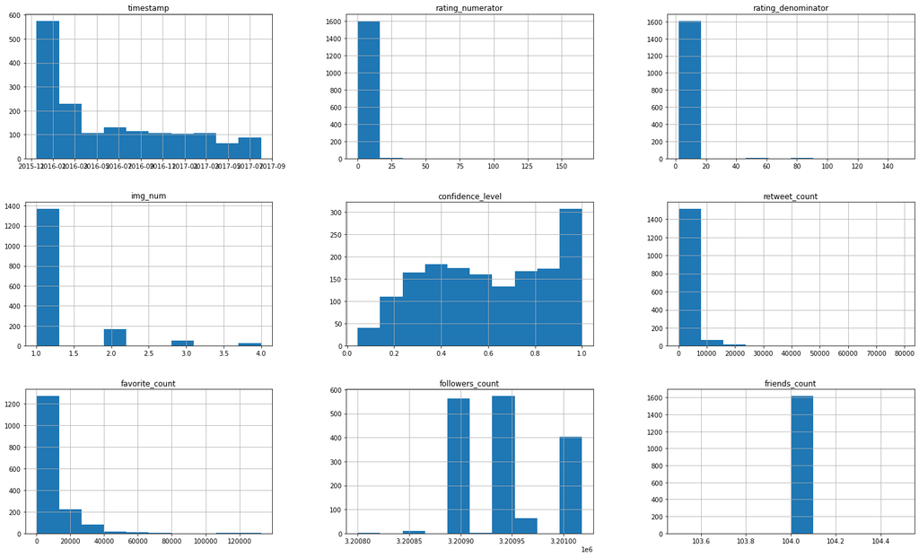

```python
master_archive.hist(figsize = (25,15));
```

```python
master_archive.describe()
```

|  | rating_numerator | rating_denominator | img_num | confidence_level | retweet_count | favorite_count | followers_count | friends_count |
| --- | --- | --- | --- | --- | --- | --- | --- | --- |
| count | 1617.000000 | 1617.000000 | 1617.000000 | 1617.000000 | 1617.000000 | 1617.000000 | 1.617000e+03 | 1617.0 |
| mean | 11.416203 | 10.482993 | 1.217069 | 0.605055 | 2771.662956 | 9071.534323 | 3.200944e+06 | 104.0 |
| std | 7.593839 | 6.438868 | 0.578497 | 0.267120 | 4793.340351 | 12467.381629 | 4.430615e+01 | 0.0 |
| min | 0.000000 | 2.000000 | 1.000000 | 0.044333 | 16.000000 | 81.000000 | 3.200800e+06 | 104.0 |
| 25% | 10.000000 | 10.000000 | 1.000000 | 0.377417 | 634.000000 | 2108.000000 | 3.200900e+06 | 104.0 |
| 50% | 11.000000 | 10.000000 | 1.000000 | 0.605437 | 1407.000000 | 4249.000000 | 3.200947e+06 | 104.0 |
| 75% | 12.000000 | 10.000000 | 1.000000 | 0.854861 | 3224.000000 | 11492.000000 | 3.200954e+06 | 104.0 |
| max | 165.000000 | 150.000000 | 4.000000 | 0.999984 | 79515.000000 | 132810.000000 | 3.201018e+06 | 104.0 |

### 1. What dog_breed is the most popular among tweets?

### 2. Find the tweets with the most and least retweet and favorites counts?

### 3. What time of the day is the account most active?

### 4. What is the relationship between the retweet count and favorite count?

```python
master_archive.dog_breed.value_counts()[:20]
```

```
golden_retriever             135
Labrador_retriever            88
Pembroke                      85
Chihuahua                     77
pug                           51
Pomeranian                    38
chow                          37
toy_poodle                    37
Samoyed                       36
malamute                      29
cocker_spaniel                26
French_bulldog                24
Chesapeake_Bay_retriever      22
miniature_pinscher            21
seat_belt                     20
German_shepherd               20
Siberian_husky                20
Staffordshire_bullterrier     19
Shetland_sheepdog             18
Maltese_dog                   18
Name: dog_breed, dtype: int64
```

```python
master_archive.dog_breed.value_counts()[-10:]
```

```
nipple          0
notebook        0
oscilloscope    0
otterhound      0
oxygen_mask     0
paddle          0
paintbrush      0
corn            0
consomme        0
zebra           0
Name: dog_breed, dtype: int64
```

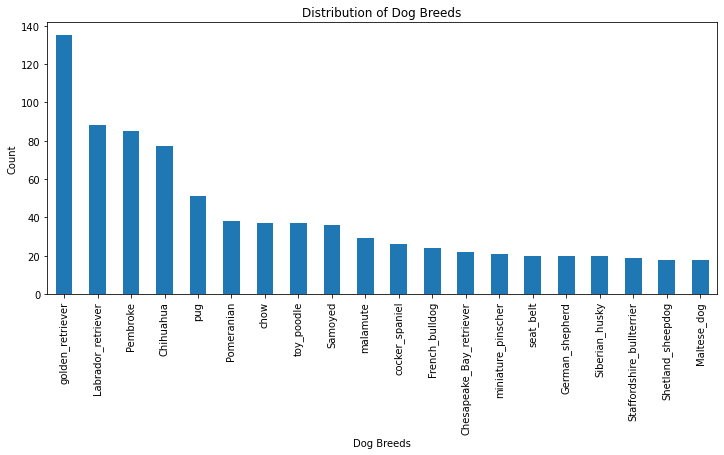

```python
master_archive.dog_breed.value_counts()[:20].plot(figsize =(12,5), kind = 'bar')
plt.title('Distribution of Dog Breeds')
plt.xlabel('Dog Breeds')
plt.ylabel('Count');
```

It is clear from the analysis above that the golden retriever is the most common/popular breed of dogs posted by the We rate dogs account.

### What tweet has the most and minimum likes respectively?

```python
max_fave = master_archive.favorite_count.max()
```

```python
master_archive[master_archive.favorite_count == max_fave]
```

|  | tweet_id | timestamp | source | text | rating_numerator | rating_denominator | name | short_urls | dog_stage | jpg_url | img_num | dog_breed | confidence_level | retweet_count | favorite_count | followers_count | friends_count | verified |
| --- | --- | --- | --- | --- | --- | --- | --- | --- | --- | --- | --- | --- | --- | --- | --- | --- | --- | --- |
| 4436 | 822872901745569793 | 2017-01-21 18:26:02+00:00 | Twitter for iPhone | Here's a super supportive puppo participating ... | 13 | 10 | NaN | https://t.co/nTz3FtorBc | puppo | https://pbs.twimg.com/media/C2tugXLXgAArJO4.jpg | 1.0 | Lakeland_terrier | 0.196015 | 48265 | 132810 | 3200894 | 104 | True |

```python
master_archive[master_archive.favorite_count == max_fave].text.to_list()
```

```
["Here's a super supportive puppo participating in the Toronto  #WomensMarch today. 13/10 "]
```

**Here's a super supportive puppo participating in the Toronto #WomensMarch today. 13/10**. This was the tweet with the most likes

```python
master_archive[master_archive.favorite_count == max_fave].jpg_url
```

```
4436    https://pbs.twimg.com/media/C2tugXLXgAArJO4.jpg
Name: jpg_url, dtype: object
```

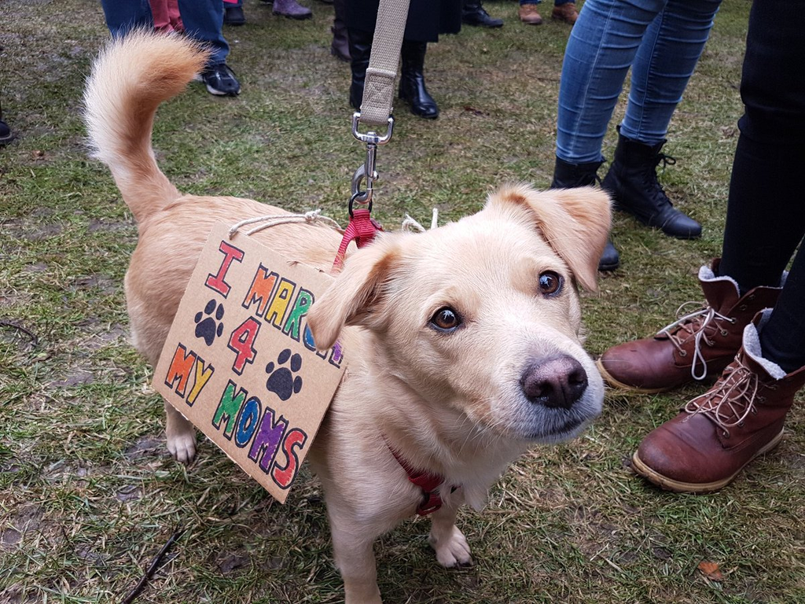

**The above image is the image contained in the tweet with the most likes.** 19/10 agree with this resolution.

```python
min_fave = master_archive.favorite_count.min()
```

```python
master_archive[master_archive.favorite_count == min_fave]
```

|  | tweet_id | timestamp | source | text | rating_numerator | rating_denominator | name | short_urls | dog_stage | jpg_url | img_num | dog_breed | confidence_level | retweet_count | favorite_count | followers_count | friends_count | verified |
| --- | --- | --- | --- | --- | --- | --- | --- | --- | --- | --- | --- | --- | --- | --- | --- | --- | --- | --- |
| 26404 | 666102155909144576 | 2015-11-16 03:55:04+00:00 | Twitter for iPhone | Oh my. Here you are seeing an Adobe Setter giv... | 11 | 10 | NaN | https://t.co/11LvqN4WLq | NaN | https://pbs.twimg.com/media/CT54YGiWUAEZnoK.jpg | 1.0 | English_setter | 0.298617 | 16 | 81 | 3201018 | 104 | True |

```python
master_archive[master_archive.favorite_count == min_fave].text.to_list()
```

```
['Oh my. Here you are seeing an Adobe Setter giving birth to twins!!! The world is an amazing place. 11/10 ']
```

```python
master_archive[master_archive.favorite_count == min_fave].jpg_url
```

```
26404    https://pbs.twimg.com/media/CT54YGiWUAEZnoK.jpg
Name: jpg_url, dtype: object
```

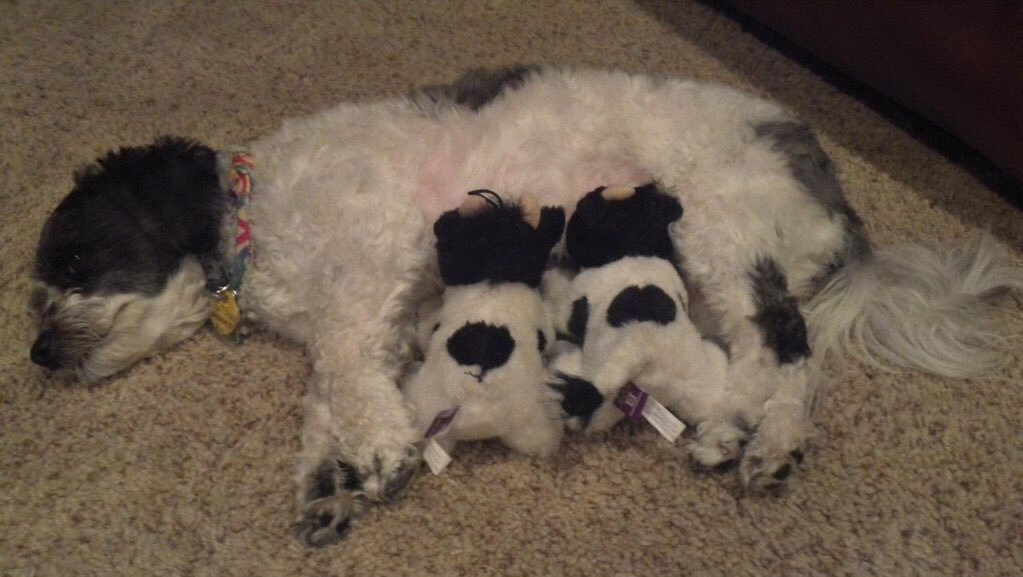

**Above is the picture linked to the tweet with the least amount of likes**

```python
max_rt = master_archive.retweet_count.max()
```

```python
master_archive[master_archive.retweet_count == max_rt]
```

|  | tweet_id | timestamp | source | text | rating_numerator | rating_denominator | name | short_urls | dog_stage | jpg_url | img_num | dog_breed | confidence_level | retweet_count | favorite_count | followers_count | friends_count | verified |
| --- | --- | --- | --- | --- | --- | --- | --- | --- | --- | --- | --- | --- | --- | --- | --- | --- | --- | --- |
| 11131 | 744234799360020481 | 2016-06-18 18:26:18+00:00 | Twitter for iPhone | Here's a doggo realizing you can stand in a po... | 13 | 10 | NaN | https://t.co/7wE9LTEXC4 | doggo | https://pbs.twimg.com/ext_tw_video_thumb/74423... | 1.0 | Labrador_retriever | 0.825333 | 79515 | 131075 | 3200943 | 104 | True |

```python
master_archive[master_archive.retweet_count == max_rt].text.to_list()
```

```
["Here's a doggo realizing you can stand in a pool. 13/10 enlightened af (vid by Tina Conrad) "]
```

```python
master_archive[master_archive.retweet_count == max_rt].short_urls
```

```
11131    https://t.co/7wE9LTEXC4
Name: short_urls, dtype: object
```

The tweet with the most retweets is a video of a dog standing in a pool after swimming for a while.

```python
min_rt = master_archive.retweet_count.min()
```

```python
master_archive[master_archive.retweet_count == min_rt]
```

|  | tweet_id | timestamp | source | text | rating_numerator | rating_denominator | name | short_urls | dog_stage | jpg_url | img_num | dog_breed | confidence_level | retweet_count | favorite_count | followers_count | friends_count | verified |
| --- | --- | --- | --- | --- | --- | --- | --- | --- | --- | --- | --- | --- | --- | --- | --- | --- | --- | --- |
| 26404 | 666102155909144576 | 2015-11-16 03:55:04+00:00 | Twitter for iPhone | Oh my. Here you are seeing an Adobe Setter giv... | 11 | 10 | NaN | https://t.co/11LvqN4WLq | NaN | https://pbs.twimg.com/media/CT54YGiWUAEZnoK.jpg | 1.0 | English_setter | 0.298617 | 16 | 81 | 3201018 | 104 | True |

```python
master_archive[master_archive.retweet_count == min_rt].text.to_list()
```

```
['Oh my. Here you are seeing an Adobe Setter giving birth to twins!!! The world is an amazing place. 11/10 ']
```

```python
master_archive[master_archive.retweet_count == min_rt].jpg_url
```

```
26404    https://pbs.twimg.com/media/CT54YGiWUAEZnoK.jpg
Name: jpg_url, dtype: object
```

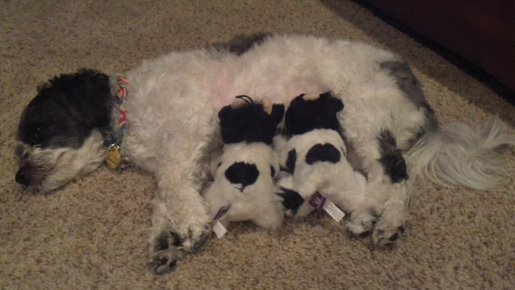

This happens to be the tweet with the least retweets. the same exact tweet with the least favorites

### When is the account mostly active in a day?

```python
sum(master_archive.tweet_id.duplicated())
```

```
0
```

```python
master_archive['timestamp'] = master_archive.timestamp.dt.hour
```

```python
timestamp = master_archive['timestamp']
time_bins = [0,6,12,18,24]
bin_names = ['twilight' , 'morning' , 'noon' , 'night' ]
master_archive['day_period'] = pd.cut(timestamp, time_bins , labels = bin_names)
```

```python
master_archive.groupby('day_period').count()
```

| day_period | tweet_id | timestamp | source | text | rating_numerator | rating_denominator | name | short_urls | dog_stage | jpg_url | img_num | dog_breed | confidence_level | retweet_count | favorite_count | followers_count | friends_count | verified |
| --- | --- | --- | --- | --- | --- | --- | --- | --- | --- | --- | --- | --- | --- | --- | --- | --- | --- | --- |
| twilight | 618 | 618 | 618 | 618 | 618 | 618 | 440 | 618 | 99 | 618 | 618 | 618 | 618 | 618 | 618 | 618 | 618 | 618 |
| morning | 0 | 0 | 0 | 0 | 0 | 0 | 0 | 0 | 0 | 0 | 0 | 0 | 0 | 0 | 0 | 0 | 0 | 0 |
| noon | 457 | 457 | 457 | 457 | 457 | 457 | 379 | 457 | 77 | 457 | 457 | 457 | 457 | 457 | 457 | 457 | 457 | 457 |
| night | 331 | 331 | 331 | 331 | 331 | 331 | 257 | 331 | 55 | 331 | 331 | 331 | 331 | 331 | 331 | 331 | 331 | 331 |

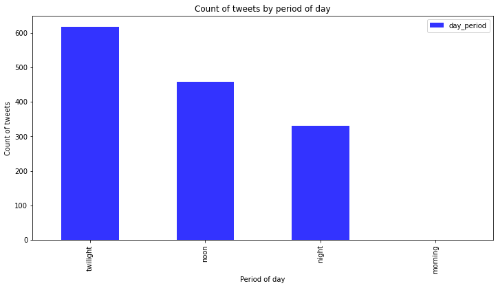

```python
plt.rcParams["figure.figsize"] = (12,6)

master_archive.day_period.value_counts().plot(kind='bar',alpha=0.8, color= 'b')
plt.legend();

plt.title('Count of tweets by period of day')
plt.xlabel('Period of day')
plt.ylabel('Count of tweets');
```

The twilight period(between 12am and 6am) is the period when the account has tweeted the most.

### What is the relationship between the retweet count and favorite count?

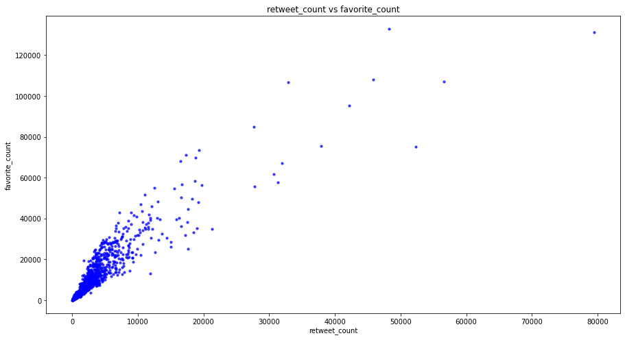

```python
plt.rcParams["figure.figsize"] = (15,8)
x = master_archive['retweet_count']
y = master_archive['favorite_count']

plt.scatter(x , y , s = 10, c = 'b' , alpha= .7)

plt.title('retweet_count vs favorite_count')
plt.xlabel('retweet_count')
plt.ylabel('favorite_count');
```

The retweets and likes increase and decrease simultaneously.